# meox1 slingshot pseudotime + tradeSeq divergence testing

Kobayashi et al. 2026

Tyrone Chen

August 05, 2026

# 1 README

> **Software version note (carried over from `README_extended.Rmd`):** `slingshot` has extremely specific install quirks, so package versions used for this document are not in perfect alignment with the rest of the manuscript’s analysis environment. Little functional impact is expected, but this is recorded here for transparency and reproducibility. Check `sessionInfo()` / your `renv.lock` snapshot from whenever this was last run if exact version pinning matters.

This is by far the largest document in `analysis_extended/` (the source script is ~1500 lines) and the most compute-heavy - it runs `slingshot` pseudotime plus `tradeSeq` GAM divergence testing (WT vs mutant) across every possible lineage start point, for the combined dataset (`D10051`) and each sample individually (`S20200` = mutant, `S20201` = wildtype). Expect a long run and a very large number of output files.

- Versions tagged `Label` have full axes/legend/title, for reference.
- Versions tagged `Strip` have all of that removed, for figure composition.
- UMAP coordinates used throughout are the dataset’s own (i.e. UMAPs were not recomputed per-sample subset).
- `start_{celltype}` reflects the assumed “start” point of the trajectory algorithm (should be the most “primitive” celltype cluster) - all celltypes are run as a candidate start for completeness/sanity-checking, not because all of them are biologically meaningful start points.

## 1.1 Outputs

All under `../output/figure_extended/slingshot/`, per `run_slingshot()` call (once for `D10051` combined, once each for `S20200`/`S20201`) and per `start_<celltype>_lin<N>` combination found. Naming follows the `meox1__<PlotType><Label|Strip>_<Description>_start_<celltype>_lin<N>.<col_name>.pdf` convention throughout, e.g.:

- `meox1__FeaLabel_Pseudotime_Contours_start_hmVEC_lin1.D10051.pdf` (+ many siblings: `Dim*`, `Bar*`, `Dens*`)
- `meox1__Table_tradeSeq_{Baseline,Divergence}_start_<celltype>_lin<N>.csv`
- `meox1__Heatmap_tradeSeq_{Baseline,Divergence}_start_<celltype>_lin<N>.pdf`
- WT-anchored variants (`run_wt_anchored_slingshot()`) follow the same convention with `WT_Anchored` in the name.

See the source script’s own header comment (preserved in the “Full output file listing” section at the very bottom of this document) for the complete, exhaustive file listing as originally catalogued.

## 1.2 Initial setup

```r
libraries <- c(
    "data.table",
    "DelayedMatrixStats",
    "dplyr",
    "ggplot2",
    "ggrepel",
    "patchwork",
    "pheatmap",
    "qs2",
    "Seurat",
    "SingleCellExperiment",
    "slingshot",
    "tradeSeq",
    "tidyverse",
    "viridis"
)

load_packages <- function(packages) {
    suppressPackageStartupMessages({
        cat(paste("Loading", packages, sep=" "), sep="\n")
        invisible(sapply(
            packages, library, character.only = TRUE, quietly = TRUE
            ))
    })
}
invisible(Sys.setenv(OPENBLAS_NUM_THREADS="1"))
load_packages(libraries)
```

[output not shown]

```r
outfile_dir <- "../output/figure_extended/slingshot/"
dir.create(outfile_dir, recursive = TRUE, showWarnings = FALSE)
```

## 1.3 tradeSeq GAM pipeline: trajectory & divergence testing

For each lineage, isolates cells that participate in it (non-`NA` pseudotime, non-zero Slingshot weight), fits a GAM per gene via `tradeSeq::fitGAM()`, tests baseline trajectory association and WT-vs-mutant “condition” divergence, and renders smoothed expression heatmaps for the top 50 significant genes from each test.

```r
run_lineage_tradeseq <- function(seurat_obj, start, lin, meta_pt, meta_weight, outfile_dir, n_top_genes = 2000) {
    cat("\n   -> [tradeSeq] Initializing GAM fit for start:", start, "lin:", lin, "\n")

    # 1. Isolate cells that actually participate in this lineage
    # We require a pseudotime value and a Slingshot weight > 0
    valid_cells <- rownames(seurat_obj@meta.data)[
        !is.na(seurat_obj@meta.data[[meta_pt]]) &
        seurat_obj@meta.data[[meta_weight]] > 0
    ]

    if (length(valid_cells) < 50) {
        cat("      -> Too few cells for robust GAM fitting. Skipping.\n")
        return()
    }

    sub_seurat <- subset(seurat_obj, cells = valid_cells)

    # 2. Extract and format condition (Genotype)
    # Ensure WT is the reference level
    sub_seurat$Genotype <- case_when(
        grepl("_1$", colnames(sub_seurat)) ~ "meox1_mutant",
        grepl("_2$", colnames(sub_seurat)) ~ "WildType"
    )
    sub_seurat$Genotype <- factor(sub_seurat$Genotype, levels = c("WildType", "meox1_mutant"))

    if (length(unique(sub_seurat$Genotype)) < 2) {
        cat("      -> Missing one genotype condition in this lineage. Skipping divergence test.\n")
        return()
    }

    # 3. Restrict gene space to save massive compute time
    sub_seurat <- FindVariableFeatures(sub_seurat, selection.method = "vst", nfeatures = n_top_genes, verbose = FALSE)
    target_genes <- VariableFeatures(sub_seurat)

    # Extract inputs for tradeSeq
    counts_matrix <- GetAssayData(sub_seurat, assay = "RNA", layer = "counts")[target_genes, ]
    pt_vec <- sub_seurat@meta.data[[meta_pt]]
    cw_vec <- sub_seurat@meta.data[[meta_weight]]
    cond_factor <- sub_seurat$Genotype

    # 4. Fit the GAM model
    # Note: nknots=5 is standard for single-cell tradeSeq balances flexibility with overfitting
    cat("      -> Fitting GAMs (this may take a few minutes)...\n")
    set.seed(42)
    sce_tradeseq <- fitGAM(
        counts = counts_matrix,
        pseudotime = as.matrix(pt_vec),
        cellWeights = as.matrix(cw_vec),
        conditions = cond_factor,
        nknots = 5,
        verbose = FALSE
    )

    # 5. TEST 1: Baseline Trajectory Association (Does it change over time at all?)
    cat("      -> Testing Baseline Trajectory Associations...\n")
    asso_res <- associationTest(sce_tradeseq)
    asso_res$Gene <- rownames(asso_res)
    asso_res <- asso_res %>%
        arrange(pvalue, desc(waldStat)) %>%
        mutate(FDR = p.adjust(pvalue, method = "fdr")) %>%
        select(Gene, waldStat, df, pvalue, FDR, meanLogFC)

    file_asso <- sprintf("%smeox1__Table_tradeSeq_Baseline_start_%s_lin%s.csv", outfile_dir, start, lin)
    write.csv(asso_res, file = file_asso, row.names = FALSE)

    # 6. TEST 2: Genotype Divergence (Does the mutant behave differently over time?)
    cat("      -> Testing Genotype Divergence (WT vs Mut)...\n")
    cond_res <- conditionTest(sce_tradeseq)
    cond_res$Gene <- rownames(cond_res)
    cond_res <- cond_res %>%
        arrange(pvalue, desc(waldStat)) %>%
        mutate(FDR = p.adjust(pvalue, method = "fdr")) %>%
        select(Gene, waldStat, df, pvalue, FDR)

    file_cond <- sprintf("%smeox1__Table_tradeSeq_Divergence_start_%s_lin%s.csv", outfile_dir, start, lin)
    write.csv(cond_res, file = file_cond, row.names = FALSE)

    # ========================================================================
    # HEATMAP GENERATION
    # ========================================================================
    cat("      -> Generating Smoothed Heatmaps...\n")

    # Helper function to generate and save heatmap
    plot_tradeseq_heatmap <- function(genes_to_plot, filename, title_text) {
        if (length(genes_to_plot) < 2) return()

        # fitGAM() can silently drop genes that fail to fit/converge, but associationTest()/
        # conditionTest() results (where genes_to_plot is selected from) can still list them -
        # filter to genes actually present in the fitted object first...
        n_requested <- length(genes_to_plot)
        genes_to_plot <- intersect(genes_to_plot, rownames(sce_tradeseq))
        n_dropped <- n_requested - length(genes_to_plot)
        if (n_dropped > 0) {
            cat(sprintf(
                "      -> %d/%d requested genes (%.1f%%) not in fitted models object for %s - dropped.\n",
                n_dropped, n_requested, 100 * n_dropped / n_requested, title_text
            ))
        }
        if (length(genes_to_plot) < 2) {
            cat("      -> Fewer than 2 fitted genes remain for", title_text, "after filtering - skipping heatmap.\n")
            return()
        }

        # ...and still guard the call itself: one bad gene subset skipping its heatmap is far
        # cheaper than losing an entire multi-hour run to a single predictSmooth() failure.
        smooth_expr <- tryCatch(
            predictSmooth(sce_tradeseq, gene = genes_to_plot, nPoints = 100, tidy = FALSE),
            error = function(e) {
                cat("      -> predictSmooth() failed for", title_text, ":", conditionMessage(e), "- skipping heatmap.\n")
                NULL
            }
        )
        if (is.null(smooth_expr)) return()

        # Scale the data row-wise (Z-score) for heatmap visualization
        mat_scaled <- t(scale(t(smooth_expr)))

        # tradeSeq outputs WT and Mutant columns contiguously.
        # Create an annotation bar to clearly separate WT vs Mutant on the heatmap
        annot_col <- data.frame(
            Genotype = factor(rep(c("WildType", "meox1_mutant"), each = 100), levels = c("WildType", "meox1_mutant"))
        )
        rownames(annot_col) <- colnames(mat_scaled)
        ann_colors <- list(Genotype = c("WildType" = "#377EB8", "meox1_mutant" = "#E41A1C"))

        draw_heatmap <- function() {
            pheatmap(
                mat_scaled,
                cluster_cols = FALSE, # MUST be false to preserve pseudotime ordering
                cluster_rows = TRUE,  # Cluster genes with similar patterns
                show_colnames = FALSE,
                annotation_col = annot_col,
                annotation_colors = ann_colors,
                color = viridis::viridis(100),
                main = title_text,
                fontsize_row = 7
            )
        }

        # draw once for the knitted document, once more into the PDF device for the file
        draw_heatmap()

        pdf(filename, width = 8, height = 10)
        draw_heatmap()
        dev.off()
    }

    # Plot top 50 Baseline Trajectory Genes
    top_asso_genes <- head(asso_res$Gene[asso_res$FDR < 0.05], 50)
    plot_tradeseq_heatmap(
        top_asso_genes,
        sprintf("%smeox1__Heatmap_tradeSeq_Baseline_start_%s_lin%s.pdf", outfile_dir, start, lin),
        sprintf("Top 50 Baseline Pseudotime Genes\n(Start: %s, Lin: %s)", start, lin)
    )

    # Plot top 50 Divergence (Mutant vs WT) Genes
    top_cond_genes <- head(cond_res$Gene[cond_res$FDR < 0.05], 50)
    plot_tradeseq_heatmap(
        top_cond_genes,
        sprintf("%smeox1__Heatmap_tradeSeq_Divergence_start_%s_lin%s.pdf", outfile_dir, start, lin),
        sprintf("Top 50 Genotype Divergence Genes\n(Start: %s, Lin: %s)", start, lin)
    )
}
```

## 1.4 Custom transition-zone barplots

Isolates a specific subset of transition zones (e.g. zones 1-3 for hmVEC lineage 1) and plots stacked + dodged percentage barplots comparing genotypes within just that subset.

```r
plot_custom_transition_zones <- function(
    master_df,
    target_zones,      # e.g., c(1, 2, 3)
    custom_colors,     # named vector mapping colors to "Transition Zone X"
    title_prefix,      # e.g., "hmVEC Lin 1"
    file_prefix,       # e.g., "Custom_hmVEC_Lin1"
    outfile_dir,
    col_name           # automatically tracks D10051 vs S20200 vs S20201
) {

    if (nrow(master_df) == 0) { return() }
    zone_names <- paste0("Transition Zone ", target_zones)
    custom_df <- master_df %>% filter(Zone %in% zone_names)

    if (nrow(custom_df) == 0) { return() }

    cat(paste0("Generating custom zone plots for: ", title_prefix, " (Dataset: ", col_name, ")...\n"))

    # automatically use whatever samples are present in master_df for this run
    custom_df <- master_df %>%
        filter(Zone %in% zone_names) %>%
        group_by(Sample, Zone) %>%
        tally(name = "Cell_Count") %>%
        ungroup()

    if (nrow(custom_df) == 0) {
        cat("   -> No cells found in the targeted zones. Skipping plot.\n")
        return()
    }

    # recalculate percentages relative only to this specific isolated subset per sample
    custom_df <- custom_df %>%
        group_by(Sample) %>%
        mutate(Sub_Total = sum(Cell_Count), Proportion = (Cell_Count / Sub_Total) * 100) %>%
        ungroup()

    custom_df$Zone <- factor(custom_df$Zone, levels = zone_names)

    custom_df <- custom_df %>%
        arrange(Sample, desc(Zone)) %>%
        group_by(Sample) %>%
        mutate(label_y_prop = cumsum(Proportion) - (0.5 * Proportion)) %>%
        ungroup()

    # stacked plot
    plt_stacked <- ggplot(custom_df, aes(x = Sample, y = Proportion, fill = Zone)) +
        geom_col(width = 0.5, color = "black", linewidth = 0.5) +
        geom_text_repel(aes(y = label_y_prop, label = ifelse(Proportion > 0, paste0(round(Proportion, 1), "%"), "")),
                        nudge_x = 0.4, direction = "y", hjust = 0, segment.size = 0.3) +
        scale_fill_manual(values = custom_colors) +
        coord_cartesian(ylim = c(0, 100)) +
        labs(title = paste0(title_prefix, " - Zones ", paste(target_zones, collapse="-"), " %"),
             x = NULL, y = "% of Selected Zones", fill = "Trajectory Regions") +
        theme_classic() +
        theme(axis.text = element_text(color = "black", size = 11),
              axis.title.y = element_text(face = "bold", size = 12),
              plot.title = element_text(face = "bold", size = 11, hjust = 0.5))

    print(plt_stacked)
    ggsave(paste0(outfile_dir, "meox1__BarLabel_", file_prefix, "_Zones", paste(target_zones, collapse=""), "_Stacked_Proportion.", col_name, ".pdf"), plot = plt_stacked, height = 5, width = 6.5)
    print(plt_stacked + NoAxes() + NoLegend() + theme(plot.title = element_blank()))
    ggsave(paste0(outfile_dir, "meox1__BarStrip_", file_prefix, "_Zones", paste(target_zones, collapse=""), "_Stacked_Proportion.", col_name, ".pdf"), plot = plt_stacked + NoAxes() + NoLegend() + theme(plot.title = element_blank()), height = 4, width = 3)

    # dodged plot
    max_prop <- max(custom_df$Proportion, na.rm = TRUE)

    plt_dodged <- ggplot(custom_df, aes(x = Sample, y = Proportion, fill = Zone)) +
        geom_col(position = position_dodge(width = 0.8), width = 0.7, color = "black", linewidth = 0.5) +
        geom_text(aes(label = ifelse(Proportion > 0, paste0(round(Proportion, 1), "%"), ""), y = Proportion + (max_prop * 0.02)),
                  position = position_dodge(width = 0.8), vjust = 0, size = 3.5) +
        scale_fill_manual(values = custom_colors) +
        coord_cartesian(ylim = c(0, min(100, max_prop * 1.15))) +
        labs(title = paste0(title_prefix, " - Zones ", paste(target_zones, collapse="-"), " Comparison"),
             x = NULL, y = "% of Selected Zones", fill = "Trajectory Regions") +
        theme_classic() +
        theme(axis.text = element_text(color = "black", size = 11),
              axis.title.y = element_text(face = "bold", size = 12),
              plot.title = element_text(face = "bold", size = 11, hjust = 0.5))

    print(plt_dodged)
    ggsave(paste0(outfile_dir, "meox1__BarLabel_", file_prefix, "_Zones", paste(target_zones, collapse=""), "_Dodged_Proportion.", col_name, ".pdf"), plot = plt_dodged, height = 5, width = 7)
    print(plt_dodged + NoAxes() + NoLegend() + theme(plot.title = element_blank()))
    ggsave(paste0(outfile_dir, "meox1__BarStrip_", file_prefix, "_Zones", paste(target_zones, collapse=""), "_Dodged_Proportion.", col_name, ".pdf"), plot = plt_dodged + NoAxes() + NoLegend() + theme(plot.title = element_blank()), height = 4, width = 4)
}
```

## 1.5 WT-anchored slingshot

A variant analysis where trajectory “zone” boundaries (density valleys) are always computed from the WT pseudotime distribution, then the same boundaries are applied to the mutant for direct, WT-anchored comparison (rather than each genotype getting its own independently-computed zones, as in the main `run_slingshot()` pipeline below).

```r
run_wt_anchored_slingshot <- function(data, col_map, col_order, outfile_dir) {
    sce <- as.SingleCellExperiment(data)
    celltype <- as.vector(unique(data@meta.data$L3_celltype))
    data$L3_celltype <- factor(data$L3_celltype, levels=col_order)
    col_name <- "WT_Anchored"

    for (start in celltype) {
        sce_run <- slingshot(
            sce,
            clusterLabels = "L3_celltype",
            reducedDim = "UMAP",
            start.clus = start
        )

        pseudotime_matrix <- slingPseudotime(sce_run)
        n_lineages <- ncol(pseudotime_matrix)

        for (lin in seq_len(n_lineages)) {

            meta <- paste0("Slingshot_Pseudotime_start_", start, "_lin", lin)
            pt_values <- pseudotime_matrix[, lin]

            cat("Processing WT-Anchored lineage:", meta, "\n")

            # 1. BUILD MASTER DATAFRAME FOR ALL CELLS
            master_zones_df <- data.frame(
                Barcode = colnames(data),
                Pseudotime = pt_values,
                Cluster = data@meta.data$L3_celltype
            ) %>%
                mutate(Sample = case_when(
                    grepl("_1$", Barcode) ~ "meox1 -/- mutant",
                    grepl("_2$", Barcode) ~ "WildType",
                    TRUE ~ "Unknown"
                )) %>%
                filter(Sample != "Unknown")

            # Split profiles
            wt_pseudotime <- master_zones_df %>% filter(Sample == "WildType", !is.na(Pseudotime)) %>% pull(Pseudotime)
            mut_pseudotime <- master_zones_df %>% filter(Sample == "meox1 -/- mutant", !is.na(Pseudotime)) %>% pull(Pseudotime)
            full_pseudotime <- master_zones_df %>% filter(!is.na(Pseudotime)) %>% pull(Pseudotime)

            if(length(wt_pseudotime) < 10) {
                cat("   -> Insufficient WT cells for density calculations. Skipping.\n")
                next
            }

            # 2. CALCULATE ALL DENSITIES & EXTRACT VALLEYS
            dens_wt <- density(wt_pseudotime, na.rm = TRUE)
            valleys <- which(diff(sign(diff(dens_wt$y))) == 2) + 1
            valley_times <- dens_wt$x[valleys]

            dens_mut  <- density(mut_pseudotime, na.rm = TRUE)
            valleys_mut <- which(diff(sign(diff(dens_mut$y))) == 2) + 1
            valley_times_mut <- dens_mut$x[valleys_mut]

            dens_full <- density(full_pseudotime, na.rm = TRUE)

            accent_palette <- c("#D32F2F", "#F57C00", "#7B1FA2", "#388E3C")

            # Setup base dataframes for plotting
            df_wt   <- data.frame(X = dens_wt$x, Y = dens_wt$y)
            df_mut  <- data.frame(X = dens_mut$x, Y = dens_mut$y)
            df_full <- data.frame(X = dens_full$x, Y = dens_full$y)

            # Create mapping dataframes for the zones to force ggplot to build a legend
            zones_wt_df <- data.frame(
                Zone = paste0("Transition Zone ", seq_along(valley_times)),
                xmin = valley_times - 0.5,
                xmax = valley_times + 0.5,
                ymin = -Inf,
                ymax = Inf
            )
            zone_colors_wt <- setNames(accent_palette[((seq_along(valley_times) - 1) %% length(accent_palette)) + 1], zones_wt_df$Zone)

            # --- PLOT 1: CLEAN WT ONLY (NO OVERLAYS) ---
            p1 <- ggplot(df_wt, aes(x = X, y = Y)) +
                geom_rect(data = zones_wt_df, aes(xmin = xmin, xmax = xmax, ymin = ymin, ymax = ymax, fill = Zone), inherit.aes = FALSE, alpha = 0.15) +
                geom_line(color = "#377EB8", linewidth = 1) +
                geom_vline(xintercept = valley_times, color = "red", linetype = "dashed") +
                scale_fill_manual(name = "Trajectory Regions", values = zone_colors_wt) +
                labs(title = paste0("WT-Only Baseline Profile\n(Start: ", start, " Lin: ", lin, ")"), x = "Pseudotime", y = "Relative Probability Density") +
                theme_classic() + theme(plot.title = element_text(hjust = 0.5, face = "bold"))
            print(p1)
            ggsave(paste0(outfile_dir, "meox1__DensLabel_WT_Anchored_Pure_WT_start_", start, "_lin", lin, ".pdf"), plot = p1, height = 5, width = 6.5)

            # --- PLOT 2: CLEAN MUTANT ONLY (NO OVERLAYS) ---
            p2 <- ggplot(df_mut, aes(x = X, y = Y)) +
                geom_rect(data = zones_wt_df, aes(xmin = xmin, xmax = xmax, ymin = ymin, ymax = ymax, fill = Zone), inherit.aes = FALSE, alpha = 0.15) +
                geom_line(color = "#E41A1C", linewidth = 1) +
                geom_vline(xintercept = valley_times, color = "red", linetype = "dashed") +
                scale_fill_manual(name = "Trajectory Regions", values = zone_colors_wt) +
                labs(title = paste0("Mutant-Only Profile mapped to WT Roadmarks\n(Start: ", start, " Lin: ", lin, ")"), x = "Pseudotime", y = "Relative Probability Density") +
                theme_classic() + theme(plot.title = element_text(hjust = 0.5, face = "bold"))
            print(p2)
            ggsave(paste0(outfile_dir, "meox1__DensLabel_WT_Anchored_Pure_Mut_start_", start, "_lin", lin, ".pdf"), plot = p2, height = 5, width = 6.5)

            # --- PLOT 3: OVERLAY - COMBINED FULL DATASET VS WT BASELINE ---
            p3 <- ggplot(df_full, aes(x = X, y = Y)) +
                geom_rect(data = zones_wt_df, aes(xmin = xmin, xmax = xmax, ymin = ymin, ymax = ymax, fill = Zone), inherit.aes = FALSE, alpha = 0.15) +
                geom_line(aes(color = "Combined Dataset"), linewidth = 1) +
                geom_line(data = df_wt, aes(x = X, y = Y, color = "WT Baseline"), linetype = "longdash", linewidth = 0.8) +
                geom_vline(xintercept = valley_times, color = "red") +
                scale_color_manual(name = "Subpopulation", values = c("Combined Dataset" = "black", "WT Baseline" = "#377EB8")) +
                scale_fill_manual(name = "Trajectory Regions", values = zone_colors_wt) +
                labs(title = paste0("Combined Pool vs WT Baseline Validation\n(Start: ", start, " Lin: ", lin, ")"), x = "Pseudotime", y = "Density") +
                theme_classic() + theme(plot.title = element_text(hjust = 0.5, face = "bold"))
            print(p3)
            ggsave(paste0(outfile_dir, "meox1__DensLabel_WT_Anchored_Overlay_Full_start_", start, "_lin", lin, ".pdf"), plot = p3, height = 5, width = 7.5)
```

```r
            # --- PLOT 4: OVERLAY - DIRECT COMPARISON (FACETED SUBPLOTS) ---
            df_compare <- bind_rows(
                df_wt %>% mutate(Genotype = "WildType Baseline"),
                df_mut %>% mutate(Genotype = "meox1 -/- Mutant")
            )
            df_compare$Genotype <- factor(df_compare$Genotype, levels = c("WildType Baseline", "meox1 -/- Mutant"))

            p4 <- ggplot(df_compare, aes(x = X, y = Y, color = Genotype)) +
                geom_rect(data = zones_wt_df, aes(xmin = xmin, xmax = xmax, ymin = ymin, ymax = ymax, fill = Zone), inherit.aes = FALSE, alpha = 0.15, color = NA) +
                geom_line(linewidth = 1) +
                geom_vline(xintercept = valley_times, color = "red", linetype = "solid") +
                scale_color_manual(name = "Genotype", values = c("WildType Baseline" = "#377EB8", "meox1 -/- Mutant" = "#E41A1C")) +
                scale_fill_manual(name = "Trajectory Regions", values = zone_colors_wt) +
                facet_wrap(~ Genotype, ncol = 1) +
                labs(title = paste0("Faceted Head-to-Head Density Alignment\n(Start: ", start, " Lin: ", lin, ")"), x = "Pseudotime", y = "Density") +
                theme_classic() +
                theme(plot.title = element_text(hjust = 0.5, face = "bold"),
                      strip.background = element_rect(fill = "grey90", color = "black"),
                      strip.text = element_text(face = "bold", size = 11))
            print(p4)
            ggsave(paste0(outfile_dir, "meox1__DensLabel_WT_Anchored_Overlay_Direct_HeadToHead_start_", start, "_lin", lin, ".pdf"), plot = p4, height = 6, width = 7.5)

            # --- PLOT 5: FULL DENSITY OVERLAY WITH WT ZONES ONLY ---
            p5 <- ggplot(df_full, aes(x = X, y = Y)) +
                geom_rect(data = zones_wt_df, aes(xmin = xmin, xmax = xmax, ymin = ymin, ymax = ymax, fill = Zone), inherit.aes = FALSE, alpha = 0.15) +
                geom_line(linewidth = 1, color = "black") +
                geom_vline(xintercept = valley_times, color = "#377EB8", linetype = "dashed", linewidth = 1) +
                scale_fill_manual(name = "Trajectory Regions", values = zone_colors_wt) +
                labs(title = paste0("Full Dataset Density with WT Zones\n(Start: ", start, " Lin: ", lin, ")"), x = "Pseudotime", y = "Density") +
                theme_classic() + theme(plot.title = element_text(hjust = 0.5, face = "bold"))
            print(p5)
            ggsave(paste0(outfile_dir, "meox1__DensLabel_WT_Anchored_Full_with_WT_Zones_start_", start, "_lin", lin, ".pdf"), plot = p5, height = 5, width = 6.5)

            # --- PLOT 6: FULL DENSITY OVERLAY WITH MUTANT ZONES ONLY ---
            zones_mut_df <- data.frame(
                Zone = paste0("Mutant Zone ", seq_along(valley_times_mut)),
                xmin = valley_times_mut - 0.5,
                xmax = valley_times_mut + 0.5,
                ymin = -Inf,
                ymax = Inf
            )
            p6 <- ggplot(df_full, aes(x = X, y = Y)) +
                geom_rect(data = zones_mut_df, aes(xmin = xmin, xmax = xmax, ymin = ymin, ymax = ymax, fill = Zone), inherit.aes = FALSE, alpha = 0.15) +
                geom_line(linewidth = 1, color = "black") +
                geom_vline(xintercept = valley_times_mut, color = "#E41A1C", linetype = "dashed", linewidth = 1) +
                scale_fill_manual(name = "Mutant Peak Regions", values = setNames(rep("#E41A1C", length(valley_times_mut)), zones_mut_df$Zone)) +
                labs(title = paste0("Full Dataset Density with Mutant Zones\n(Start: ", start, " Lin: ", lin, ")"), x = "Pseudotime", y = "Density") +
                theme_classic() + theme(plot.title = element_text(hjust = 0.5, face = "bold"))
            print(p6)
            ggsave(paste0(outfile_dir, "meox1__DensLabel_WT_Anchored_Full_with_Mutant_Zones_start_", start, "_lin", lin, ".pdf"), plot = p6, height = 5, width = 6.5)

            # --- PLOT 7: FULL DENSITY OVERLAY WITH BOTH ZONES ALIGNED ---
            wt_lines <- data.frame(val = valley_times, type = "WT Zone Boundary")
            mut_lines <- data.frame(val = valley_times_mut, type = "Mutant Zone Boundary")
            all_lines <- rbind(wt_lines, mut_lines)

            p7 <- ggplot(df_full, aes(x = X, y = Y)) +
                geom_line(linewidth = 1, color = "black") +
                geom_vline(data = all_lines, aes(xintercept = val, color = type), linetype = "dashed", linewidth = 1) +
                scale_color_manual(values = c("WT Zone Boundary" = "#377EB8", "Mutant Zone Boundary" = "#E41A1C")) +
                labs(title = paste0("Full Density with WT vs Mutant Zone Alignment\n(Start: ", start, " Lin: ", lin, ")"), x = "Pseudotime", y = "Density", color = "Calculated Boundary") +
                theme_classic() + theme(plot.title = element_text(hjust = 0.5, face = "bold"))
            print(p7)
            ggsave(paste0(outfile_dir, "meox1__DensLabel_WT_Anchored_Full_with_Both_Zones_start_", start, "_lin", lin, ".pdf"), plot = p7, height = 5, width = 7.5)

            # 3. ASSIGN INTENSITY CLASSIFICATIONS BY ZONE BOUNDARIES
            master_zones_df <- master_zones_df %>%
                mutate(Zone = case_when(
                    is.na(Pseudotime) ~ "Trajectory NA (Unmapped)",
                    TRUE ~ "Core/Other Cells"
                ))

            master_zones_df$Sample <- factor(master_zones_df$Sample, levels = c("meox1 -/- mutant", "WildType"))

            # Using WT valley times to assign zones for the final barplots as this is the baseline
            for (i in seq_along(valley_times)) {
                v_time <- valley_times[i]
                is_in_zone <- !is.na(master_zones_df$Pseudotime) & (abs(master_zones_df$Pseudotime - v_time) < 0.5)
                master_zones_df$Zone[is_in_zone] <- paste0("Transition Zone ", i)
            }

            # ========================================================================
            # WT-ANCHORED UMAP CONTOURS (With Contour Density Legends)
            # ========================================================================
            cat("   -> Generating WT-Anchored UMAP Contours...\n")
```

```r
            # 1. Prepare data
            umap_embed <- as.data.frame(Embeddings(data, reduction = "umap"))
            colnames(umap_embed)[1:2] <- c("umap_1", "umap_2")
            umap_embed$Barcode <- rownames(umap_embed)
            umap_df <- master_zones_df %>% left_join(umap_embed, by = "Barcode")
            max_pt <- max(umap_df$Pseudotime, na.rm = TRUE)

            # Ensure Zone levels match the palette exactly
            umap_df$Zone <- factor(umap_df$Zone, levels = names(zone_colors_wt))

            # 2. Base UMAP Plot
            p_umap <- ggplot(umap_df %>% arrange(Pseudotime), aes(x = umap_1, y = umap_2)) +
                geom_point(aes(color = Pseudotime), size = 0.8, alpha = 0.6) +
                scale_color_viridis_c(option = "plasma", na.value = "grey90", limits = c(0, max_pt)) +
                theme_classic() +
                labs(title = paste0("WT-Anchored UMAP Contours\n(Start: ", start, " Lin: ", lin, ")"),
                     x = "UMAP 1", y = "UMAP 2") +
                theme(plot.title = element_text(hjust = 0.5, face = "bold"))

            # 3. Add Zones mapping fill to density level, and linetype to the Zone
            for (i in seq_along(valley_times)) {
                z_label <- paste0("Transition Zone ", i)
                zone_subdata <- umap_df %>% filter(Zone == z_label)

                if (nrow(zone_subdata) > 5) {
                    p_umap <- p_umap + stat_density_2d(
                        data = zone_subdata,
                        aes(x = umap_1, y = umap_2, fill = after_stat(level), linetype = Zone),
                        geom = "polygon", alpha = 0.12, bins = 4,
                        color = zone_colors_wt[z_label], linewidth = 0.8
                    )
                }
            }

            # 4. Integrate Legends & Scales matching your original formatting
            p_umap <- p_umap +
                scale_fill_gradient(name = "Contour Density", low = "#ECEFF1", high = "#37474F") +
                scale_linetype_manual(name = "Trajectory Regions", values = setNames(rep("solid", length(valley_times)), names(zone_colors_wt)), drop = FALSE) +
                guides(
                    color = guide_colorbar(title = "Pseudotime", order = 1),
                    linetype = guide_legend(order = 2, override.aes = list(color = unname(zone_colors_wt), fill = NA, linewidth = 1.5)),
                    fill = guide_colorbar(order = 3)
                )

            # 5. Save Combined Plot
            print(p_umap)
            ggsave(paste0(outfile_dir, "meox1__DimLabel_WT_Anchored_Contours_Combined_start_", start, "_lin", lin, ".pdf"),
                   plot = p_umap, height = 7, width = 8.5)

            # 6. Save Split (Faceted) Plot
            p_umap_split <- p_umap + facet_wrap(~ Sample) +
                theme(strip.background = element_rect(fill = "grey90", color = "black"),
                      strip.text = element_text(face = "bold", size = 11))

            print(p_umap_split)
            ggsave(paste0(outfile_dir, "meox1__DimLabel_WT_Anchored_Contours_Split_start_", start, "_lin", lin, ".pdf"),
                   plot = p_umap_split, height = 6, width = 12.5)

            # 4. COMPUTE SUMMARIES AND PLOT UPDATED COUNTS + PERCENTAGE BARPLOTS
            zone_names <- c(paste0("Transition Zone ", seq_along(valley_times)), "Core/Other Cells", "Trajectory NA (Unmapped)")

            # Isolate target zones for the focused presentation
            target_zones_list <- paste0("Transition Zone ", seq_along(valley_times))

            barplot_data <- master_zones_df %>%
                filter(Zone %in% target_zones_list) %>%
                group_by(Sample, Zone) %>%
                summarise(Count = n(), .groups = 'drop') %>%
                group_by(Sample) %>%
                mutate(
                    TotalInSample = sum(Count),
                    Percentage = (Count / TotalInSample) * 100
                )

            if (nrow(barplot_data) > 0) {

                # Make dynamic palette for stacked bars
                zone_colors <- c("Transition Zone 1" = "#D32F2F", "Transition Zone 2" = "#F57C00", "Transition Zone 3" = "#7B1FA2", "Transition Zone 4" = "#388E3C")

                bp <- ggplot(barplot_data, aes(x = Sample, y = Percentage, fill = Zone)) +
                    geom_bar(stat = "identity", position = "stack", width = 0.6, color = "black", size = 0.3) +
                    # Add string text mapping directly over stacks containing both % and count (n)
                    geom_text(
                        aes(label = paste0(sprintf("%.1f", Percentage), "%\n(n=", Count, ")")),
                        position = position_stack(vjust = 0.5),
                        size = 3.2,
                        fontface = "bold",
                        color = "white"
                    ) +
                    scale_fill_manual(values = zone_colors) +
                    labs(
                        title = paste0("WT-Anchored Zone Allocations\n(Start: ", start, " Lin: ", lin, ")"),
                        x = "Genotype Pool",
                        y = "Proportional Composition (%)"
                    ) +
                    theme_classic() +
                    theme(
                        plot.title = element_text(hjust = 0.5, face = "bold"),
                        axis.text = element_text(color = "black", size = 10)
                    )

                print(bp)
                ggsave(paste0(outfile_dir, "meox1__BarLabel_WT_Anchored_Quantified_Proportions_start_", start, "_lin", lin, ".pdf"), plot = bp, height = 6, width = 5.5)
            }

            # --- HELPER FUNCTION EXECUTIONS ---
            has_wt  <- "WildType" %in% unique(master_zones_df$Sample)
            has_mut <- "meox1 -/- mutant" %in% unique(master_zones_df$Sample)

            # hmVEC Lin 1
            if (start == "hmVEC" && lin == 1) {
                if (has_wt && has_mut) {
                    plot_custom_transition_zones(
                        master_df      = master_zones_df,
                        target_zones   = c(1, 2, 3),
                        custom_colors  = c("Transition Zone 1" = "#D32F2F", "Transition Zone 2" = "#F57C00", "Transition Zone 3" = "#7B1FA2"),
                        title_prefix   = "WT-Anchored hmVEC Lin 1 (Combined)",
                        file_prefix    = "Custom_WT_Anchored_hmVEC_Lin1",
                        col_name       = col_name,
                        outfile_dir    = outfile_dir
                    )
                }
            }
```

```r
            # mVEC Lin 1
            if (start == "mVEC" && lin == 1) {
                if (has_wt && has_mut) {
                    plot_custom_transition_zones(
                        master_df      = master_zones_df,
                        target_zones   = c(1, 2),
                        custom_colors  = c("Transition Zone 1" = "#D32F2F", "Transition Zone 2" = "#F57C00"),
                        title_prefix   = "WT-Anchored mVEC Lin 1 (Combined)",
                        file_prefix    = "Custom_WT_Anchored_mVEC_Lin1",
                        col_name       = col_name,
                        outfile_dir    = outfile_dir
                    )
                }
            }

            # mVEC Lin 2
            if (start == "mVEC" && lin == 2) {
                if (has_wt && has_mut) {
                    plot_custom_transition_zones(
                        master_df      = master_zones_df,
                        target_zones   = c(1, 2),
                        custom_colors  = c("Transition Zone 1" = "#D32F2F", "Transition Zone 2" = "#F57C00"),
                        title_prefix   = "WT-Anchored mVEC Lin 2 (Combined)",
                        file_prefix    = "Custom_WT_Anchored_mVEC_Lin2",
                        col_name       = col_name,
                        outfile_dir    = outfile_dir
                    )
                }
            }
        }
    }
}
```

## 1.6 Main slingshot pipeline

The core per-dataset/per-sample pipeline: dataset-level composition barplots, then for every candidate start celltype and every lineage found, computes pseudotime, finds density-valley “transition zones”, classifies cells into `Mature/Core` / `Transitional` / `Unrelated`, calls `run_lineage_tradeseq()`, and renders the full set of Dim/Fea/Dens/Bar plots (labelled + stripped) plus the hmVEC/mVEC custom zone comparisons.

```r
run_slingshot <- function(data, col_map, col_order, col_name) {
    sce <- as.SingleCellExperiment(data)
    celltype <- as.vector(unique(data@meta.data$L3_celltype))
    data$L3_celltype <- factor(data$L3_celltype, levels=col_order)

    # dataset-level composition barplots (unified scale)
    has_mutant <- any(grepl("_1$", colnames(data)))
    has_wt     <- any(grepl("_2$", colnames(data)))

    if (nrow(data) > 0) {
        cat("Generating dataset-level composition barplots...\n")

        comp_df <- data.frame(Barcode = colnames(data), Cluster = data@meta.data$L3_celltype) %>%
            mutate(Sample = case_when(grepl("_1$", Barcode) ~ "meox1 -/- mutant",
                                      grepl("_2$", Barcode) ~ "WildType",
                                      TRUE ~ "Unknown")) %>%
            filter(Sample != "Unknown")

        comp_df$Sample <- factor(comp_df$Sample, levels = c("meox1 -/- mutant", "WildType"))
        sample_colors <- c("meox1 -/- mutant" = "#E41A1C", "WildType" = "#377EB8")

        # 1. calculate Total Composition
        tot_df <- comp_df %>%
            group_by(Sample) %>%
            tally(name = "Cell_Count") %>%
            mutate(Total = sum(Cell_Count),
                   Proportion = (Cell_Count / Total) * 100,
                   X_Category = "Total Dataset")

        # 2. calculate Cluster Composition
        clust_df <- comp_df %>%
            group_by(Cluster, Sample) %>%
            tally(name = "Cell_Count") %>%
            group_by(Cluster) %>%
            mutate(Total = sum(Cell_Count),
                   Proportion = (Cell_Count / Total) * 100,
                   X_Category = as.character(Cluster)) %>%
            ungroup() %>%
            select(-Cluster)

        # 3. combine into a single dataframe
        combined_df <- bind_rows(tot_df, clust_df)

        # 4. factor X_Category so "Total Dataset" is first
        combined_df$X_Category <- factor(combined_df$X_Category, levels = c("Total Dataset", col_order))

        # 5. calculate manual Y positions for stacked labels
        combined_df <- combined_df %>%
            arrange(X_Category, desc(Sample)) %>%
            group_by(X_Category) %>%
            mutate(label_y = cumsum(Cell_Count) - (0.5 * Cell_Count))

        # single absolute
        p_combined_abs <- ggplot(combined_df, aes(x = X_Category, y = Cell_Count, fill = Sample)) +
            geom_col(width = 0.6, color = "black", linewidth = 0.5) +
            geom_text_repel(data = subset(combined_df, X_Category == "Total Dataset"),
                            aes(y = label_y, label = ifelse(Cell_Count > 0, Cell_Count, "")),
                            nudge_x = 0.60, direction = "y", hjust = 0, segment.size = 0.3) +
            geom_text_repel(data = subset(combined_df, X_Category != "Total Dataset"),
                            aes(y = label_y, label = ifelse(Cell_Count > 0, Cell_Count, "")),
                            nudge_x = 0.35, direction = "y", hjust = 0, segment.size = 0.3) +
            scale_fill_manual(values = sample_colors) +
            labs(title = "Cells per Cluster (Including Total)", x = "Cluster / Group", y = "Absolute Number of Cells") +
            theme_classic() +
            theme(axis.text.x = element_text(angle = 45, hjust = 1, color = "black"),
                  axis.text.y = element_text(color = "black"),
                  axis.title = element_text(face="bold"),
                  plot.title = element_text(hjust=0.5, face="bold"))

        # single proportion
        p_combined_prop <- ggplot(combined_df, aes(x = X_Category, y = Proportion, fill = Sample)) +
            geom_col(width = 0.6, color = "black", linewidth = 0.5) +
            scale_fill_manual(values = sample_colors) +
            coord_cartesian(ylim = c(0, 100)) +
            labs(title = "Proportion per Cluster (Including Total)", x = "Cluster / Group", y = "% of Group") +
            theme_classic() +
            theme(axis.text.x = element_text(angle = 45, hjust = 1, color = "black"),
                  axis.text.y = element_text(color = "black"),
                  axis.title = element_text(face="bold"),
                  plot.title = element_text(hjust=0.5, face="bold"))

        print(p_combined_abs)
        ggsave(paste0(outfile_dir, "meox1__BarLabel_Combined_Total_and_Cluster_Absolute.", col_name, ".pdf"), p_combined_abs, height=5, width=7)
        print(p_combined_prop)
        ggsave(paste0(outfile_dir, "meox1__BarLabel_Combined_Total_and_Cluster_Proportion.", col_name, ".pdf"), p_combined_prop, height=5, width=7)

        p_combined_abs_strip <- p_combined_abs + NoAxes() + NoLegend() + theme(plot.title=element_blank())
        print(p_combined_abs_strip)
        ggsave(paste0(outfile_dir, "meox1__BarStrip_Combined_Total_and_Cluster_Absolute.", col_name, ".pdf"), p_combined_abs_strip, height=4, width=6)

        p_combined_prop_strip <- p_combined_prop + NoAxes() + NoLegend() + theme(plot.title=element_blank())
        print(p_combined_prop_strip)
        ggsave(paste0(outfile_dir, "meox1__BarStrip_Combined_Total_and_Cluster_Proportion.", col_name, ".pdf"), p_combined_prop_strip, height=4, width=6)

        # per-sample unified composition plots (total + clusters)
        cat("Generating per-sample unified composition barplots...\n")

        for (current_sample in levels(comp_df$Sample)) {

            sample_df <- comp_df %>% filter(Sample == current_sample)

            if (nrow(sample_df) > 0) {

                # added group_by(sample) so the column isn't dropped by tally()
                tot_s <- sample_df %>%
                    group_by(Sample) %>%
                    tally(name = "Cell_Count") %>%
                    mutate(Total = Cell_Count, Proportion = 100, X_Category = paste0("Total (", current_sample, ")"))

                # added sample grouping, and added ungroup() before mutate so proportions calculate correctly
                clust_s <- sample_df %>%
                    group_by(Cluster, Sample) %>%
                    tally(name = "Cell_Count") %>%
                    ungroup() %>%
                    mutate(Total = sum(Cell_Count), Proportion = (Cell_Count / Total) * 100, X_Category = as.character(Cluster)) %>%
                    select(-Cluster)
```

```r
                combined_s <- bind_rows(tot_s, clust_s)
                combined_s$X_Category <- factor(combined_s$X_Category, levels = c(paste0("Total (", current_sample, ")"), col_order))
                combined_s <- combined_s %>% mutate(label_y = Cell_Count * 0.5)
                safe_sample_name <- gsub("[ /]", "_", current_sample)

                p_samp_abs <- ggplot(combined_s, aes(x = X_Category, y = Cell_Count, fill = Sample)) +
                    geom_col(width = 0.6, color = "black", linewidth = 0.5) +
                    geom_text_repel(data = subset(combined_s, X_Category == paste0("Total (", current_sample, ")")), aes(y = label_y, label = ifelse(Cell_Count > 0, Cell_Count, "")), nudge_x = 0.35, direction = "y", hjust = 0, segment.size = 0.3) +
                    geom_text_repel(data = subset(combined_s, X_Category != paste0("Total (", current_sample, ")")), aes(y = label_y, label = ifelse(Cell_Count > 0, Cell_Count, "")), nudge_x = 0.35, direction = "y", hjust = 0, segment.size = 0.3) +
                    scale_fill_manual(values = sample_colors) +
                    labs(title = paste0(current_sample, " - Cells per Cluster (Including Total)"), x = "Cluster", y = "Absolute Number of Cells") +
                    theme_classic() + theme(axis.text.x = element_text(angle = 45, hjust = 1, color = "black"), axis.text.y = element_text(color = "black"), axis.title = element_text(face="bold"), plot.title = element_text(hjust=0.5, face="bold"), legend.position = "none")

                p_samp_prop <- ggplot(combined_s, aes(x = X_Category, y = Proportion, fill = Sample)) +
                    geom_col(width = 0.6, color = "black", linewidth = 0.5) +
                    scale_fill_manual(values = sample_colors) +
                    coord_cartesian(ylim = c(0, 100)) +
                    labs(title = paste0(current_sample, " - Proportion per Cluster (Including Total)"), x = "Cluster", y = "% of Sample") +
                    theme_classic() + theme(axis.text.x = element_text(angle = 45, hjust = 1, color = "black"), axis.text.y = element_text(color = "black"), axis.title = element_text(face="bold"), plot.title = element_text(hjust=0.5, face="bold"), legend.position = "none")

                print(p_samp_abs)
                ggsave(paste0(outfile_dir, "meox1__BarLabel_Sample_", safe_sample_name, "_Unified_Absolute.", col_name, ".pdf"), p_samp_abs, height=5, width=7)
                print(p_samp_prop)
                ggsave(paste0(outfile_dir, "meox1__BarLabel_Sample_", safe_sample_name, "_Unified_Proportion.", col_name, ".pdf"), p_samp_prop, height=5, width=7)
                print(p_samp_abs + NoAxes() + NoLegend() + theme(plot.title=element_blank()))
                ggsave(paste0(outfile_dir, "meox1__BarStrip_Sample_", safe_sample_name, "_Unified_Absolute.", col_name, ".pdf"), p_samp_abs + NoAxes() + NoLegend() + theme(plot.title=element_blank()), height=4, width=6)
                print(p_samp_prop + NoAxes() + NoLegend() + theme(plot.title=element_blank()))
                ggsave(paste0(outfile_dir, "meox1__BarStrip_Sample_", safe_sample_name, "_Unified_Proportion.", col_name, ".pdf"), p_samp_prop + NoAxes() + NoLegend() + theme(plot.title=element_blank()), height=4, width=6)
            }
        }
    }

    for (start in celltype) {
        sce <- slingshot(
            sce,
            clusterLabels = "L3_celltype",
            reducedDim = "UMAP",
            start.clus = start
        )

        pseudotime_matrix <- slingPseudotime(sce)
        n_lineages <- ncol(pseudotime_matrix)
        max_pseudotime_global <- max(pseudotime_matrix, na.rm = TRUE)

        curves <- slingCurves(sce, as.df = TRUE)
        curves <- curves %>%
            group_by(Lineage) %>%
            arrange(Order, .by_group = TRUE)

        weights_matrix <- slingCurveWeights(SlingshotDataSet(sce))

        for (lin in seq_len(n_lineages)) {

            meta <- paste0("Slingshot_Pseudotime_start_", start, "_lin", lin)
            data[[meta]] <- pseudotime_matrix[, lin]

            cat("Processing lineage:", meta, "\n")
            print(summary(data[[meta]]))

            lineage_curve <- curves %>% filter(Lineage == lin)
            dens <- density(data@meta.data[[meta]], na.rm = TRUE)

            valleys <- which(diff(sign(diff(dens$y))) == 2) + 1
            valley_times <- dens$x[valleys]

            meta_data <- data@meta.data
            cluster_transition <- paste0("Cluster_Boundaries_start_", start, "_lin", lin)
            meta_data[[cluster_transition]] <- "Core Cluster"

            for (v in valley_times) {
                meta_data[[cluster_transition]][
                    abs(meta_data[[meta]] - v) < 0.5
                ] <- "Transitional Boundary"
            }
            data[[cluster_transition]] <- meta_data[[cluster_transition]]

            umap_embed <- as.data.frame(Embeddings(data, reduction = "umap"))
            colnames(umap_embed)[1:2] <- c("umap_1", "umap_2")
            umap_embed$State <- meta_data[[cluster_transition]]

            transition_zones_df <- data.frame(
                umap_1     = umap_embed$umap_1,
                umap_2     = umap_embed$umap_2,
                Pseudotime = data@meta.data[[meta]]
            ) %>%
                mutate(Zone_ID = "Other")

            for (z_idx in seq_along(valley_times)) {
                v_time <- valley_times[z_idx]
                is_in_valley <- !is.na(transition_zones_df$Pseudotime) & (abs(transition_zones_df$Pseudotime - v_time) < 0.5)
                transition_zones_df$Zone_ID[is_in_valley] <- paste0("Transition Zone ", z_idx)
            }

            transition_zones_only <- transition_zones_df %>% filter(Zone_ID != "Other")

            accent_palette <- c("#D32F2F", "#F57C00", "#7B1FA2", "#388E3C")
            zone_names <- paste0("Transition Zone ", seq_along(valley_times))

            p_dens_df <- data.frame(
                pseudotime_axis = dens$x,
                density_axis    = dens$y
            )
```

```r
            # minima profile
            plt_minima <- ggplot(p_dens_df, aes(x = pseudotime_axis, y = density_axis))
            for (i in seq_along(valley_times)) {
                v <- valley_times[i]
                rect_color <- accent_palette[((i - 1) %% length(accent_palette)) + 1]
                plt_minima <- plt_minima +
                    annotate("rect", xmin = v - 0.5, xmax = v + 0.5,
                             ymin = -Inf, ymax = Inf, alpha = 0.2, fill = rect_color)
            }
            plt_minima <- plt_minima +
                geom_line(linewidth = 0.8, color = "black") +
                geom_vline(xintercept = valley_times, color = "red", linewidth = 1, linetype = "solid") +
                labs(title = paste0("Local Minima Profile (Start: ", start, " Lin: ", lin, ")"), x = "Pseudotime", y = "Density") +
                theme_classic() +
                theme(plot.title = element_text(hjust = 0.5, face = "bold", size = 12),
                      axis.text = element_text(color = "black", size = 11),
                      axis.title = element_text(face = "bold", size = 12))

            print(plt_minima)
            ggsave(paste0(outfile_dir, "meox1__DensLabel_Minima_start_", start, "_lin", lin, ".", col_name, ".pdf"), plot = plt_minima, height = 5, width = 6)
            print(plt_minima + NoAxes() + theme(plot.title = element_blank()))
            ggsave(paste0(outfile_dir, "meox1__DensStrip_Minima_start_", start, "_lin", lin, ".", col_name, ".pdf"), plot = plt_minima + NoAxes() + theme(plot.title = element_blank()), height = 4, width = 5)
            rm(p_dens_df, plt_minima)

            # dynamic lineage weights
            weights_col_name <- paste0("Lineage_Weights_start_", start, "_lin", lin)
            data[[weights_col_name]] <- weights_matrix[, lin]

            meta_data <- data@meta.data
            transition_col_name <- paste0("Transition_State_start_", start, "_lin", lin)

            meta_data <- meta_data %>%
                mutate(
                    "{transition_col_name}" := case_when(
                        is.na(.data[[meta]]) | .data[[weights_col_name]] == 0 ~ "Unrelated",
                        .data[[weights_col_name]] > 0.05 & .data[[weights_col_name]] < 0.95 ~ "Transitional",
                        .data[[weights_col_name]] >= 0.95 ~ "Mature/Core",
                        TRUE ~ "Unrelated"
                    )
                )
            data[[transition_col_name]] <- meta_data[[transition_col_name]]

            # run tradeseq
            run_lineage_tradeseq(
                seurat_obj = data,
                start = start,
                lin = lin,
                meta_pt = meta,
                meta_weight = weights_col_name,
                outfile_dir = outfile_dir
            )

            # dimplot celltype
            plt_dim <- DimPlot(data, group.by = "L3_celltype", cols=col_map)
            plt_dim_arr <- plt_dim + geom_path(data = lineage_curve, aes(x = umap_1, y = umap_2), size = 1.2, color = "black", arrow = arrow(length = unit(0.3, "cm"), type = "closed", ends = "last"))
            print(plt_dim_arr)
            ggsave(paste0(outfile_dir, "meox1__DimLabel_Slingshot_Pseudotime_start_", start, "_lin", lin, ".", col_name, ".pdf"), plot = plt_dim_arr, height = 7, width = 7)
            print(plt_dim_arr + NoAxes() + NoLegend() + theme(plot.title = element_blank()))
            ggsave(paste0(outfile_dir, "meox1__DimStrip_Slingshot_Pseudotime_start_", start, "_lin", lin, ".", col_name, ".pdf"), plot = plt_dim_arr + NoAxes() + NoLegend() + theme(plot.title = element_blank()), height = 5, width = 5)

            # dimplot celltype contours
            plt_dim_arr <- plt_dim + geom_path(data = lineage_curve, aes(x = umap_1, y = umap_2), size = 1.2, color = "black", arrow = arrow(length = unit(0.3, "cm"), type = "closed", ends = "last"))
            for (i in seq_along(valley_times)) {
                z_label <- paste0("Transition Zone ", i)
                zone_subdata <- transition_zones_only %>% filter(Zone_ID == z_label)
                plt_dim_arr <- plt_dim_arr + stat_density_2d(data = zone_subdata, aes(x = umap_1, y = umap_2, fill = after_stat(level), linetype = Zone_ID), geom = "polygon", alpha = 0.12, bins = 4, color = accent_palette[((i - 1) %% length(accent_palette)) + 1], linewidth = 1.0)
            }
            plt_dim_arr <- plt_dim_arr + scale_fill_gradient(name = "Contour Density", low = "#ECEFF1", high = "#37474F") + scale_linetype_manual(name = "Trajectory Regions", values = setNames(rep("solid", length(valley_times)), zone_names)) + guides(color = guide_legend(order = 1, override.aes = list(alpha = 1, fill = NA, size = 4, shape = 16, linetype = 0, stroke = 0)), fill = guide_colorbar(order = 3), linetype = guide_legend(order = 2, override.aes = list(color = accent_palette[1:length(valley_times)], linewidth = 1.5)))
            print(plt_dim_arr)
            ggsave(paste0(outfile_dir, "meox1__DimLabel_Celltype_Contours_start_", start, "_lin", lin, ".", col_name, ".pdf"), plot = plt_dim_arr, height = 7, width = 8)
            print(plt_dim_arr + NoAxes() + NoLegend() + theme(plot.title = element_blank()))
            ggsave(paste0(outfile_dir, "meox1__DimStrip_Celltype_Contours_start_", start, "_lin", lin, ".", col_name, ".pdf"), plot = plt_dim_arr + NoAxes() + NoLegend() + theme(plot.title = element_blank()), height = 5, width = 5)

            # dimplot cluster transition zones
            plt_dim_trans <- DimPlot(data, group.by = cluster_transition)
            plt_dim_arr <- plt_dim_trans + geom_path(data = lineage_curve, aes(x = umap_1, y = umap_2), size = 1.2, color = "black", arrow = arrow(length = unit(0.3, "cm"), type = "closed", ends = "last"))
            print(plt_dim_arr)
            ggsave(paste0(outfile_dir, "meox1__DimLabel_Cluster_Transition_start_", start, "_lin", lin, ".", col_name, ".pdf"), plot = plt_dim_arr, height = 7, width = 7)
            print(plt_dim_arr + NoAxes() + NoLegend() + theme(plot.title = element_blank()))
            ggsave(paste0(outfile_dir, "meox1__DimStrip_Cluster_Transition_start_", start, "_lin", lin, ".", col_name, ".pdf"), plot = plt_dim_arr + NoAxes() + NoLegend() + theme(plot.title = element_blank()), height = 5, width = 5)
```

```r
            # dimplot transition state
            plt_dim_state <- DimPlot(data, group.by = transition_col_name, cols = c("Transitional" = "red", "Mature/Core" = "lightgrey", "Unrelated" = "whitesmoke"))
            plt_dim_arr <- plt_dim_state + geom_path(data = lineage_curve, aes(x = umap_1, y = umap_2), size = 1.2, color = "black", arrow = arrow(length = unit(0.3, "cm"), type = "closed", ends = "last"))
            print(plt_dim_arr)
            ggsave(paste0(outfile_dir, "meox1__DimLabel_Transition_State_start_", start, "_lin", lin, ".", col_name, ".pdf"), plot = plt_dim_arr, height = 7, width = 7)
            print(plt_dim_arr + NoAxes() + NoLegend() + theme(plot.title = element_blank()))
            ggsave(paste0(outfile_dir, "meox1__DimStrip_Transition_State_start_", start, "_lin", lin, ".", col_name, ".pdf"), plot = plt_dim_arr + NoAxes() + NoLegend() + theme(plot.title = element_blank()), height = 5, width = 5)

            # feaplot transition score weights
            plt_fea_weights <- FeaturePlot(data, features = weights_col_name) + scale_color_viridis_c(option = "plasma")
            plt_fea_arr <- plt_fea_weights + geom_path(data = lineage_curve, aes(x = umap_1, y = umap_2), size = 1.2, color = "black", arrow = arrow(length = unit(0.3, "cm"), type = "closed", ends = "last"))
            print(plt_fea_arr)
            ggsave(paste0(outfile_dir, "meox1__FeaLabel_Transition_Scores_start_", start, "_lin", lin, ".", col_name, ".pdf"), plot = plt_fea_arr, height = 7, width = 7)
            print(plt_fea_arr + NoAxes() + NoLegend() + theme(plot.title = element_blank()))
            ggsave(paste0(outfile_dir, "meox1__FeaStrip_Transition_Scores_start_", start, "_lin", lin, ".", col_name, ".pdf"), plot = plt_fea_arr + NoAxes() + NoLegend() + theme(plot.title = element_blank()), height = 5, width = 5)

            # feaplot pseudotime scores
            plt_fea_pseudo <- FeaturePlot(data, features = meta) + scale_color_viridis_c(option = "plasma", limits = c(0, max_pseudotime_global))
            plt_fea_arr <- plt_fea_pseudo + geom_path(data = lineage_curve, aes(x = umap_1, y = umap_2), size = 1.2, color = "black", arrow = arrow(length = unit(0.3, "cm"), type = "closed", ends = "last"))
            print(plt_fea_arr)
            ggsave(paste0(outfile_dir, "meox1__FeaLabel_Pseudotime_Scores_start_", start, "_lin", lin, ".", col_name, ".pdf"), plot = plt_fea_arr, height = 7, width = 7)
            print(plt_fea_arr + NoAxes() + NoLegend() + theme(plot.title = element_blank()))
            ggsave(paste0(outfile_dir, "meox1__FeaStrip_Pseudotime_Scores_start_", start, "_lin", lin, ".", col_name, ".pdf"), plot = plt_fea_arr + NoAxes() + NoLegend() + theme(plot.title = element_blank()), height = 5, width = 5)

            # feaplot pseudotime contours
            plt_fea_contour <- plt_fea_pseudo
            for (i in seq_along(valley_times)) {
                z_label <- paste0("Transition Zone ", i)
                zone_subdata <- transition_zones_only %>% filter(Zone_ID == z_label)
                plt_fea_contour <- plt_fea_contour + stat_density_2d(data = zone_subdata, aes(x = umap_1, y = umap_2, fill = after_stat(level), linetype = Zone_ID), geom = "polygon", alpha = 0.12, bins = 4, color = accent_palette[((i - 1) %% length(accent_palette)) + 1], linewidth = 1.0)
            }
            plt_fea_contour_arr <- plt_fea_contour + scale_fill_gradient(name = "Contour Density", low = "#ECEFF1", high = "#37474F") + scale_linetype_manual(name = "Trajectory Regions", values = setNames(rep("solid", length(valley_times)), zone_names)) + guides(color = guide_colorbar(title = "Pseudotime", order = 1), fill = guide_colorbar(order = 3), linetype = guide_legend(order = 2, override.aes = list(color = accent_palette[1:length(valley_times)], linewidth = 1.5)))
            print(plt_fea_contour_arr)
            ggsave(paste0(outfile_dir, "meox1__FeaLabel_Pseudotime_Contours_start_", start, "_lin", lin, ".", col_name, ".pdf"), plot = plt_fea_contour_arr, height = 7, width = 8)
            print(plt_fea_contour_arr + NoAxes() + NoLegend() + theme(plot.title = element_blank()))
            ggsave(paste0(outfile_dir, "meox1__FeaStrip_Pseudotime_Contours_start_", start, "_lin", lin, ".", col_name, ".pdf"), plot = plt_fea_contour_arr + NoAxes() + NoLegend() + theme(plot.title = element_blank()), height = 5, width = 5)

            # barplots cell proportion (transition zones)
            if (nrow(data) > 0) {

                master_zones_df <- data.frame(
                    Barcode = colnames(data),
                    Pseudotime = data@meta.data[[meta]],
                    Cluster = data@meta.data$L3_celltype
                ) %>%
                    mutate(Sample = case_when(grepl("_1$", Barcode) ~ "meox1 -/- mutant", grepl("_2$", Barcode) ~ "WildType", TRUE ~ "Unknown"),
                           Zone = case_when(is.na(Pseudotime) ~ "Trajectory NA (Unmapped)", TRUE ~ "Core/Other Cells")) %>%
                    filter(Sample != "Unknown")

                master_zones_df$Sample <- factor(master_zones_df$Sample, levels = c("meox1 -/- mutant", "WildType"))
                sample_colors <- c("meox1 -/- mutant" = "#E41A1C", "WildType" = "#377EB8")

                for (i in seq_along(valley_times)) {
                    v_time <- valley_times[i]
                    is_in_zone <- !is.na(master_zones_df$Pseudotime) & (abs(master_zones_df$Pseudotime - v_time) < 0.5)
                    master_zones_df$Zone[is_in_zone] <- paste0("Transition Zone ", i)
                }

                sample_baselines <- master_zones_df %>% group_by(Sample) %>% tally(name = "Total_Sample_Cells")

                max_proportion_global <- 0
                for (i in seq_along(valley_times)) {
                    z_label <- paste0("Transition Zone ", i)
                    current_prop <- master_zones_df %>% filter(Zone == z_label) %>% group_by(Sample) %>% tally() %>% left_join(sample_baselines, by = "Sample") %>% mutate(Proportion = (n / Total_Sample_Cells) * 100) %>% pull(Proportion)
                    if (length(current_prop) > 0) { max_proportion_global <- max(max_proportion_global, max(current_prop)) }
                }
                max_proportion_global <- min(100, max_proportion_global * 1.05)
```

```r
                for (i in seq_along(valley_times)) {
                    v_time <- valley_times[i]
                    z_label <- paste0("Transition Zone ", i)

                    indiv_summary <- master_zones_df %>%
                        mutate(Indiv_Status = case_when(Zone == z_label ~ z_label, Zone == "Trajectory NA (Unmapped)" ~ "Trajectory NA (Unmapped)", TRUE ~ "Core/Other Cells")) %>%
                        group_by(Sample, Indiv_Status) %>% tally(name = "Cell_Count") %>% ungroup() %>%
                        left_join(sample_baselines, by = "Sample") %>% mutate(Proportion = (Cell_Count / Total_Sample_Cells) * 100)

                    isolated_zone <- indiv_summary %>% filter(Indiv_Status == z_label)

                    plt_isolated <- ggplot(isolated_zone, aes(x = Sample, y = Proportion, fill = Sample)) +
                        geom_col(width = 0.5, color = "black", linewidth = 0.5) +
                        scale_fill_manual(values = sample_colors) +
                        coord_cartesian(ylim = c(0, max_proportion_global)) +
                        labs(title = paste0("Transition Zone ", i, " (Pseudotime ~ ", round(v_time, 2), ")"), x = NULL, y = "% of Sample Cells") +
                        theme_classic() + theme(legend.position = "none", axis.text = element_text(color = "black", size = 11), axis.title.y = element_text(face = "bold", size = 12), plot.title = element_text(face = "bold", size = 11, hjust = 0.5))

                    print(plt_isolated)
                    ggsave(paste0(outfile_dir, "meox1__BarLabel_Transition_Zone_", i, "_Proportion_start_", start, "_lin", lin, ".", col_name, ".pdf"), plot = plt_isolated, height = 5, width = 5)
                    print(plt_isolated + NoAxes() + NoLegend() + theme(plot.title = element_blank()))
                    ggsave(paste0(outfile_dir, "meox1__BarStrip_Transition_Zone_", i, "_Proportion_start_", start, "_lin", lin, ".", col_name, ".pdf"), plot = plt_isolated + NoAxes() + NoLegend() + theme(plot.title = element_blank()), height = 4, width = 3)

                    indiv_summary$Indiv_Status <- factor(indiv_summary$Indiv_Status, levels = c("Trajectory NA (Unmapped)", "Core/Other Cells", z_label))

                    indiv_summary <- indiv_summary %>% arrange(Sample, desc(Indiv_Status)) %>% group_by(Sample) %>% mutate(label_y = cumsum(Cell_Count) - 0.5 * Cell_Count)

                    plt_stacked_indiv <- ggplot(indiv_summary, aes(x = Sample, y = Cell_Count, fill = Indiv_Status)) +
                        geom_col(width = 0.6, color = "black", linewidth = 0.5) +
                        geom_text_repel(aes(y = label_y, label = ifelse(Cell_Count > 0, Cell_Count, "")), nudge_x = 0.45, direction = "y", hjust = 0, segment.size = 0.3) +
                        scale_fill_manual(values = setNames(c("#D32F2F", "#CFD8DC", "#37474F"), c(z_label, "Core/Other Cells", "Trajectory NA (Unmapped)"))) +
                        labs(title = paste0("Dataset Alignment Fit: Transition Zone ", i), x = NULL, y = "Total Number of Cells", fill = "State Definition") +
                        theme_classic() + theme(axis.text = element_text(color = "black", size = 11), axis.title.y = element_text(face = "bold", size = 12), plot.title = element_text(face = "bold", size = 11, hjust = 0.5))

                    print(plt_stacked_indiv)
                    ggsave(paste0(outfile_dir, "meox1__BarLabel_Transition_Zone_", i, "_StackedTotal_start_", start, "_lin", lin, ".", col_name, ".pdf"), plot = plt_stacked_indiv, height = 5, width = 6)
                    print(plt_stacked_indiv + NoAxes() + NoLegend() + theme(plot.title = element_blank()))
                    ggsave(paste0(outfile_dir, "meox1__BarStrip_Transition_Zone_", i, "_StackedTotal_start_", start, "_lin", lin, ".", col_name, ".pdf"), plot = plt_stacked_indiv + NoAxes() + NoLegend() + theme(plot.title = element_blank()), height = 4, width = 3)

                    # cluster per zone
                    zone_df <- master_zones_df %>% filter(Zone == z_label)

                    if (nrow(zone_df) > 0) {
                        tot_z <- zone_df %>% group_by(Sample) %>% tally(name = "Cell_Count") %>% mutate(Total = sum(Cell_Count), Proportion = (Cell_Count / Total) * 100, X_Category = paste0("Total (Zone ", i, ")"))
                        clust_z <- zone_df %>% group_by(Cluster, Sample) %>% tally(name = "Cell_Count") %>% group_by(Cluster) %>% mutate(Total = sum(Cell_Count), Proportion = (Cell_Count / Total) * 100, X_Category = as.character(Cluster)) %>% ungroup() %>% select(-Cluster)

                        combined_z <- bind_rows(tot_z, clust_z)
                        combined_z$X_Category <- factor(combined_z$X_Category, levels = c(paste0("Total (Zone ", i, ")"), col_order))

                        combined_z <- combined_z %>% arrange(X_Category, desc(Sample)) %>% group_by(X_Category) %>% mutate(label_y = cumsum(Cell_Count) - (0.5 * Cell_Count))

                        p_z_abs <- ggplot(combined_z, aes(x = X_Category, y = Cell_Count, fill = Sample)) +
                            geom_col(width = 0.6, color = "black", linewidth = 0.5) +
                            geom_text_repel(data = subset(combined_z, X_Category == paste0("Total (Zone ", i, ")")), aes(y = label_y, label = ifelse(Cell_Count > 0, Cell_Count, "")), nudge_x = 0.35, direction = "y", hjust = 0, segment.size = 0.3) +
                            geom_text_repel(data = subset(combined_z, X_Category != paste0("Total (Zone ", i, ")")), aes(y = label_y, label = ifelse(Cell_Count > 0, Cell_Count, "")), nudge_x = 0.35, direction = "y", hjust = 0, segment.size = 0.3) +
                            scale_fill_manual(values = sample_colors) +
                            labs(title = paste0("Zone ", i, " Cells per Cluster (Including Total)"), x = "Cluster", y = "Absolute Number of Cells") +
                            theme_classic() + theme(axis.text.x = element_text(angle = 45, hjust = 1, color = "black"), axis.text.y = element_text(color = "black"), axis.title = element_text(face="bold"), plot.title = element_text(hjust=0.5, face="bold"), legend.position = "none")
```

```r
                        p_z_prop <- ggplot(combined_z, aes(x = X_Category, y = Proportion, fill = Sample)) +
                            geom_col(width = 0.6, color = "black", linewidth = 0.5) +
                            scale_fill_manual(values = sample_colors) +
                            coord_cartesian(ylim = c(0, 100)) +
                            labs(title = paste0("Proportion per Cluster (Zone ", i, ")"), x = "Cluster", y = "% of Zone") +
                            theme_classic() + theme(axis.text.x = element_text(angle = 45, hjust = 1, color = "black"), axis.text.y = element_text(color = "black"), axis.title = element_text(face="bold"), plot.title = element_text(hjust=0.5, face="bold"), legend.position = "none")

                        print(p_z_abs)
                        ggsave(paste0(outfile_dir, "meox1__BarLabel_Transition_Zone_", i, "_Unified_Absolute_start_", start, "_lin", lin, ".", col_name, ".pdf"), p_z_abs, height=5, width=7)
                        print(p_z_prop)
                        ggsave(paste0(outfile_dir, "meox1__BarLabel_Transition_Zone_", i, "_Unified_Proportion_start_", start, "_lin", lin, ".", col_name, ".pdf"), p_z_prop, height=5, width=7)
                        print(p_z_abs + NoAxes() + NoLegend() + theme(plot.title=element_blank()))
                        ggsave(paste0(outfile_dir, "meox1__BarStrip_Transition_Zone_", i, "_Unified_Absolute_start_", start, "_lin", lin, ".", col_name, ".pdf"), p_z_abs + NoAxes() + NoLegend() + theme(plot.title=element_blank()), height=4, width=6)
                        print(p_z_prop + NoAxes() + NoLegend() + theme(plot.title=element_blank()))
                        ggsave(paste0(outfile_dir, "meox1__BarStrip_Transition_Zone_", i, "_Unified_Proportion_start_", start, "_lin", lin, ".", col_name, ".pdf"), p_z_prop + NoAxes() + NoLegend() + theme(plot.title=element_blank()), height=4, width=6)
                    }
                }

                combined_summary <- master_zones_df %>% group_by(Sample, Zone) %>% tally(name = "Cell_Count") %>% ungroup()
                zone_levels <- c("Trajectory NA (Unmapped)", "Core/Other Cells", paste0("Transition Zone ", seq_along(valley_times)))
                combined_summary$Zone <- factor(combined_summary$Zone, levels = zone_levels)
                combined_summary <- combined_summary %>% arrange(Sample, desc(Zone)) %>% group_by(Sample) %>% mutate(label_y = cumsum(Cell_Count) - 0.5 * Cell_Count)

                zone_colors <- c("Trajectory NA (Unmapped)" = "#37474F", "Core/Other Cells" = "#CFD8DC")
                for (i in seq_along(valley_times)) { zone_colors[paste0("Transition Zone ", i)] <- accent_palette[((i - 1) %% length(accent_palette)) + 1] }

                plt_combined <- ggplot(combined_summary, aes(x = Sample, y = Cell_Count, fill = Zone)) +
                    geom_col(width = 0.6, color = "black", linewidth = 0.5) +
                    geom_text_repel(aes(y = label_y, label = ifelse(Cell_Count > 0, Cell_Count, "")), nudge_x = 0.45, direction = "y", hjust = 0, segment.size = 0.3) +
                    scale_fill_manual(values = zone_colors) +
                    labs(title = paste0("Transition Zones Combined (Start: ", start, " Lin: ", lin, ")"), x = NULL, y = "Total Number of Cells", fill = "Trajectory Regions") +
                    theme_classic() + theme(axis.text = element_text(color = "black", size = 11), axis.title.y = element_text(face = "bold", size = 12), plot.title = element_text(face = "bold", size = 12, hjust = 0.5))

                print(plt_combined)
                ggsave(paste0(outfile_dir, "meox1__BarLabel_All_Transition_Zones_Stacked_start_", start, "_lin", lin, ".", col_name, ".pdf"), plot = plt_combined, height = 5, width = 6.5)
                print(plt_combined + NoAxes() + NoLegend() + theme(plot.title = element_blank()))
                ggsave(paste0(outfile_dir, "meox1__BarStrip_All_Transition_Zones_Stacked_start_", start, "_lin", lin, ".", col_name, ".pdf"), plot = plt_combined + NoAxes() + NoLegend() + theme(plot.title = element_blank()), height = 4, width = 3)

                # 1. isolate just the transition zones
                zones_only_summary <- master_zones_df %>%
                    filter(grepl("Transition Zone", Zone)) %>%
                    group_by(Sample, Zone) %>%
                    tally(name = "Cell_Count") %>%
                    ungroup()

                # calculate proportions based strictly on isolated zone totals per sample
                zones_only_summary <- zones_only_summary %>%
                    group_by(Sample) %>%
                    mutate(Zone_Total = sum(Cell_Count),
                           Proportion = (Cell_Count / Zone_Total) * 100) %>%
                    ungroup()

                # update factor levels to just the zones
                zone_only_levels <- paste0("Transition Zone ", seq_along(valley_times))
                zones_only_summary$Zone <- factor(zones_only_summary$Zone, levels = zone_only_levels)

                # calculate Y positions for stacked versions (both absolute and percentage)
                zones_only_summary <- zones_only_summary %>%
                    arrange(Sample, desc(Zone)) %>%
                    group_by(Sample) %>%
                    mutate(label_y_abs = cumsum(Cell_Count) - (0.5 * Cell_Count),
                           label_y_prop = cumsum(Proportion) - (0.5 * Proportion)) %>%
                    ungroup()

                # plot a1 stacked zones only absolute
                plt_stacked_zones_only <- ggplot(zones_only_summary, aes(x = Sample, y = Cell_Count, fill = Zone)) +
                    geom_col(width = 0.6, color = "black", linewidth = 0.5) +
                    geom_text_repel(aes(y = label_y_abs, label = ifelse(Cell_Count > 0, Cell_Count, "")),
                                    nudge_x = 0.45, direction = "y", hjust = 0, segment.size = 0.3) +
                    scale_fill_manual(values = zone_colors) +
                    labs(title = paste0("Transition Zones Only (Start: ", start, " Lin: ", lin, ")"), x = NULL, y = "Total Number of Cells", fill = "Trajectory Regions") +
                    theme_classic() +
                    theme(axis.text = element_text(color = "black", size = 11),
                          axis.title.y = element_text(face = "bold", size = 12),
                          plot.title = element_text(face = "bold", size = 12, hjust = 0.5))
```

```r
                print(plt_stacked_zones_only)
                ggsave(paste0(outfile_dir, "meox1__BarLabel_Isolated_Zones_Stacked_start_", start, "_lin", lin, ".", col_name, ".pdf"), plot = plt_stacked_zones_only, height = 5, width = 6.5)
                print(plt_stacked_zones_only + NoAxes() + NoLegend() + theme(plot.title = element_blank()))
                ggsave(paste0(outfile_dir, "meox1__BarStrip_Isolated_Zones_Stacked_start_", start, "_lin", lin, ".", col_name, ".pdf"), plot = plt_stacked_zones_only + NoAxes() + NoLegend() + theme(plot.title = element_blank()), height = 4, width = 3)

                # plot a2 stacked zones only percentage
                plt_stacked_zones_prop <- ggplot(zones_only_summary, aes(x = Sample, y = Proportion, fill = Zone)) +
                    geom_col(width = 0.6, color = "black", linewidth = 0.5) +
                    geom_text_repel(aes(y = label_y_prop, label = ifelse(Proportion > 0, paste0(round(Proportion, 1), "%"), "")),
                                    nudge_x = 0.45, direction = "y", hjust = 0, segment.size = 0.3) +
                    scale_fill_manual(values = zone_colors) +
                    coord_cartesian(ylim = c(0, 100)) +
                    labs(title = paste0("Transition Zones Composition % (Start: ", start, " Lin: ", lin, ")"), x = NULL, y = "% of Transition Zone Cells", fill = "Trajectory Regions") +
                    theme_classic() +
                    theme(axis.text = element_text(color = "black", size = 11),
                          axis.title.y = element_text(face = "bold", size = 12),
                          plot.title = element_text(face = "bold", size = 12, hjust = 0.5))

                print(plt_stacked_zones_prop)
                ggsave(paste0(outfile_dir, "meox1__BarLabel_Isolated_Zones_Stacked_Proportion_start_", start, "_lin", lin, ".", col_name, ".pdf"), plot = plt_stacked_zones_prop, height = 5, width = 6.5)
                print(plt_stacked_zones_prop + NoAxes() + NoLegend() + theme(plot.title = element_blank()))
                ggsave(paste0(outfile_dir, "meox1__BarStrip_Isolated_Zones_Stacked_Proportion_start_", start, "_lin", lin, ".", col_name, ".pdf"), plot = plt_stacked_zones_prop + NoAxes() + NoLegend() + theme(plot.title = element_blank()), height = 4, width = 3)

                # plot b side by side zones only absolute
                max_count <- max(zones_only_summary$Cell_Count, na.rm = TRUE)

                plt_dodged_zones_only <- ggplot(zones_only_summary, aes(x = Sample, y = Cell_Count, fill = Zone)) +
                    geom_col(position = position_dodge(width = 0.8), width = 0.7, color = "black", linewidth = 0.5) +
                    geom_text(aes(label = ifelse(Cell_Count > 0, Cell_Count, ""), y = Cell_Count + (max_count * 0.02)),
                              position = position_dodge(width = 0.8), vjust = 0, size = 3.5) +
                    scale_fill_manual(values = zone_colors) +
                    labs(title = paste0("Transition Zones by Sample (Start: ", start, " Lin: ", lin, ")"), x = NULL, y = "Total Number of Cells", fill = "Trajectory Regions") +
                    theme_classic() +
                    theme(axis.text = element_text(color = "black", size = 11),
                          axis.title.y = element_text(face = "bold", size = 12),
                          plot.title = element_text(face = "bold", size = 12, hjust = 0.5))

                print(plt_dodged_zones_only)
                ggsave(paste0(outfile_dir, "meox1__BarLabel_Isolated_Zones_Dodged_start_", start, "_lin", lin, ".", col_name, ".pdf"), plot = plt_dodged_zones_only, height = 5, width = 7)
                print(plt_dodged_zones_only + NoAxes() + NoLegend() + theme(plot.title = element_blank()))
                ggsave(paste0(outfile_dir, "meox1__BarStrip_Isolated_Zones_Dodged_start_", start, "_lin", lin, ".", col_name, ".pdf"), plot = plt_dodged_zones_only + NoAxes() + NoLegend() + theme(plot.title = element_blank()), height = 4, width = 4)

                # plot b side by side zones only percentage
                max_prop <- max(zones_only_summary$Proportion, na.rm = TRUE)

                plt_dodged_zones_prop <- ggplot(zones_only_summary, aes(x = Sample, y = Proportion, fill = Zone)) +
                    geom_col(position = position_dodge(width = 0.8), width = 0.7, color = "black", linewidth = 0.5) +
                    geom_text(aes(label = ifelse(Proportion > 0, paste0(round(Proportion, 1), "%"), ""), y = Proportion + (max_prop * 0.02)),
                              position = position_dodge(width = 0.8), vjust = 0, size = 3.5) +
                    scale_fill_manual(values = zone_colors) +
                    coord_cartesian(ylim = c(0, min(100, max_prop * 1.15))) +
                    labs(title = paste0("Transition Zones % by Sample (Start: ", start, " Lin: ", lin, ")"), x = NULL, y = "% of Transition Zone Cells", fill = "Trajectory Regions") +
                    theme_classic() +
                    theme(axis.text = element_text(color = "black", size = 11),
                          axis.title.y = element_text(face = "bold", size = 12),
                          plot.title = element_text(face = "bold", size = 12, hjust = 0.5))

                print(plt_dodged_zones_prop)
                ggsave(paste0(outfile_dir, "meox1__BarLabel_Isolated_Zones_Dodged_Proportion_start_", start, "_lin", lin, ".", col_name, ".pdf"), plot = plt_dodged_zones_prop, height = 5, width = 7)
                print(plt_dodged_zones_prop + NoAxes() + NoLegend() + theme(plot.title = element_blank()))
                ggsave(paste0(outfile_dir, "meox1__BarStrip_Isolated_Zones_Dodged_Proportion_start_", start, "_lin", lin, ".", col_name, ".pdf"), plot = plt_dodged_zones_prop + NoAxes() + NoLegend() + theme(plot.title = element_blank()), height = 4, width = 4)

                dataset_zones_only <- master_zones_df %>%
                    filter(grepl("Transition Zone", Zone)) %>%
                    group_by(Zone) %>%
                    tally(name = "Cell_Count") %>%
                    ungroup()
```

```r
                dataset_zones_only$Zone <- factor(dataset_zones_only$Zone, levels = zone_only_levels)
                max_ds_count <- max(dataset_zones_only$Cell_Count, na.rm = TRUE)

                plt_dataset_zones <- ggplot(dataset_zones_only, aes(x = Zone, y = Cell_Count, fill = Zone)) +
                    geom_col(color = "black", linewidth = 0.5, width = 0.6) +
                    geom_text(aes(label = ifelse(Cell_Count > 0, Cell_Count, ""), y = Cell_Count + (max_ds_count * 0.02)),
                              vjust = 0, size = 4) +
                    scale_fill_manual(values = zone_colors) +
                    labs(title = paste0("Dataset Cells per Transition Zone (", start, " Lin: ", lin, ")"),
                         x = NULL, y = "Total Number of Cells") +
                    theme_classic() +
                    theme(axis.text.x = element_text(angle = 45, hjust = 1, color = "black", size = 11),
                          axis.text.y = element_text(color = "black", size = 11),
                          axis.title.y = element_text(face = "bold", size = 12),
                          plot.title = element_text(face = "bold", size = 12, hjust = 0.5),
                          legend.position = "none") # Legend omitted since x-axis explains it

                print(plt_dataset_zones)
                ggsave(paste0(outfile_dir, "meox1__BarLabel_Isolated_Zones_DatasetLevel_start_", start, "_lin", lin, ".", col_name, ".pdf"), plot = plt_dataset_zones, height = 5, width = 5)
                print(plt_dataset_zones + NoAxes() + theme(plot.title = element_blank()))
                ggsave(paste0(outfile_dir, "meox1__BarStrip_Isolated_Zones_DatasetLevel_start_", start, "_lin", lin, ".", col_name, ".pdf"), plot = plt_dataset_zones + NoAxes() + theme(plot.title = element_blank()), height = 4, width = 4)

                # hmVEC lineage 1 only (zones 1, 2, 3)
                if (start == "hmVEC" && lin == 1) {
                    cat("Generating custom 3-zone percentage plots for hmVEC lineage 1...\n")

                    hmvec_3zones <- master_zones_df %>%
                        filter(Zone %in% c("Transition Zone 1", "Transition Zone 2", "Transition Zone 3")) %>%
                        group_by(Sample, Zone) %>% tally(name = "Cell_Count") %>% ungroup()

                    hmvec_3zones <- hmvec_3zones %>%
                        group_by(Sample) %>%
                        mutate(Sub_Total = sum(Cell_Count), Proportion = (Cell_Count / Sub_Total) * 100) %>% ungroup()

                    hmvec_3zones$Zone <- factor(hmvec_3zones$Zone, levels = c("Transition Zone 1", "Transition Zone 2", "Transition Zone 3"))

                    hmvec_3zones <- hmvec_3zones %>%
                        arrange(Sample, desc(Zone)) %>%
                        group_by(Sample) %>% mutate(label_y_prop = cumsum(Proportion) - (0.5 * Proportion)) %>% ungroup()

                    # override custom color mapping for this specific plot
                    hmvec_colors <- c(
                        "Transition Zone 1" = "#D32F2F",
                        "Transition Zone 2" = "#F57C00",
                        "Transition Zone 3" = "#7B1FA2"
                    )

                    plt_hmvec_stacked <- ggplot(hmvec_3zones, aes(x = Sample, y = Proportion, fill = Zone)) +
                        geom_col(width = 0.5, color = "black", linewidth = 0.5) +
                        geom_text_repel(aes(y = label_y_prop, label = ifelse(Proportion > 0, paste0(round(Proportion, 1), "%"), "")), nudge_x = 0.4, direction = "y", hjust = 0, segment.size = 0.3) +
                        scale_fill_manual(values = hmvec_colors) +
                        coord_cartesian(ylim = c(0, 100)) +
                        labs(title = "hmVEC Lin 1 - Zones 1-3 Composition %", x = NULL, y = "% of Selected Zones", fill = "Trajectory Regions") +
                        theme_classic() + theme(axis.text = element_text(color = "black", size = 11), axis.title.y = element_text(face = "bold", size = 12), plot.title = element_text(face = "bold", size = 11, hjust = 0.5))

                    print(plt_hmvec_stacked)
                    ggsave(paste0(outfile_dir, "meox1__BarLabel_Custom_hmVEC_Lin1_Zones123_Stacked_Proportion.", col_name, ".pdf"), plot = plt_hmvec_stacked, height = 5, width = 6.5)
                    print(plt_hmvec_stacked + NoAxes() + NoLegend() + theme(plot.title = element_blank()))
                    ggsave(paste0(outfile_dir, "meox1__BarStrip_Custom_hmVEC_Lin1_Zones123_Stacked_Proportion.", col_name, ".pdf"), plot = plt_hmvec_stacked + NoAxes() + NoLegend() + theme(plot.title = element_blank()), height = 4, width = 3)

                    max_hmvec_prop <- max(hmvec_3zones$Proportion, na.rm = TRUE)
                    plt_hmvec_dodged <- ggplot(hmvec_3zones, aes(x = Sample, y = Proportion, fill = Zone)) +
                        geom_col(position = position_dodge(width = 0.8), width = 0.7, color = "black", linewidth = 0.5) +
                        geom_text(aes(label = ifelse(Proportion > 0, paste0(round(Proportion, 1), "%"), ""), y = Proportion + (max_hmvec_prop * 0.02)), position = position_dodge(width = 0.8), vjust = 0, size = 3.5) +
                        scale_fill_manual(values = hmvec_colors) +
                        coord_cartesian(ylim = c(0, min(100, max_hmvec_prop * 1.15))) +
                        labs(title = "hmVEC Lin 1 - Zones 1-3 % Comparison", x = NULL, y = "% of Selected Zones", fill = "Trajectory Regions") +
                        theme_classic() + theme(axis.text = element_text(color = "black", size = 11), axis.title.y = element_text(face = "bold", size = 12), plot.title = element_text(face = "bold", size = 11, hjust = 0.5))

                    print(plt_hmvec_dodged)
                    ggsave(paste0(outfile_dir, "meox1__BarLabel_Custom_hmVEC_Lin1_Zones123_Dodged_Proportion.", col_name, ".pdf"), plot = plt_hmvec_dodged, height = 5, width = 7)
                    print(plt_hmvec_dodged + NoAxes() + NoLegend() + theme(plot.title = element_blank()))
                    ggsave(paste0(outfile_dir, "meox1__BarStrip_Custom_hmVEC_Lin1_Zones123_Dodged_Proportion.", col_name, ".pdf"), plot = plt_hmvec_dodged + NoAxes() + NoLegend() + theme(plot.title = element_blank()), height = 4, width = 4)
```

```r
                    rm(hmvec_3zones, plt_hmvec_stacked, plt_hmvec_dodged)
                }

                # mVEC lin1, reuse previous code
                if (start == "mVEC" && lin == 1) {
                    cat("Generating custom 2-zone percentage plots for mVEC lineage 1...\n")

                    mvec_2zones <- master_zones_df %>%
                        filter(Zone %in% c("Transition Zone 1", "Transition Zone 2")) %>%
                        group_by(Sample, Zone) %>% tally(name = "Cell_Count") %>% ungroup()

                    mvec_2zones <- mvec_2zones %>%
                        group_by(Sample) %>%
                        mutate(Sub_Total = sum(Cell_Count), Proportion = (Cell_Count / Sub_Total) * 100) %>% ungroup()

                    mvec_2zones$Zone <- factor(mvec_2zones$Zone, levels = c("Transition Zone 1", "Transition Zone 2"))

                    mvec_2zones <- mvec_2zones %>%
                        arrange(Sample, desc(Zone)) %>%
                        group_by(Sample) %>% mutate(label_y_prop = cumsum(Proportion) - (0.5 * Proportion)) %>% ungroup()

                    # override: custom color mapping for this specific plot
                    mvec_colors <- c(
                        "Transition Zone 1" = "#D32F2F",
                        "Transition Zone 2" = "#F57C00"
                    )

                    plt_mvec_stacked <- ggplot(mvec_2zones, aes(x = Sample, y = Proportion, fill = Zone)) +
                        geom_col(width = 0.5, color = "black", linewidth = 0.5) +
                        geom_text_repel(aes(y = label_y_prop, label = ifelse(Proportion > 0, paste0(round(Proportion, 1), "%"), "")), nudge_x = 0.4, direction = "y", hjust = 0, segment.size = 0.3) +
                        scale_fill_manual(values = mvec_colors) +
                        coord_cartesian(ylim = c(0, 100)) +
                        labs(title = "mVEC Lin 1 - Zones 1-2 Composition %", x = NULL, y = "% of Selected Zones", fill = "Trajectory Regions") +
                        theme_classic() + theme(axis.text = element_text(color = "black", size = 11), axis.title.y = element_text(face = "bold", size = 12), plot.title = element_text(face = "bold", size = 11, hjust = 0.5))

                    print(plt_mvec_stacked)
                    ggsave(paste0(outfile_dir, "meox1__BarLabel_Custom_mVEC_Lin1_Zones12_Stacked_Proportion.", col_name, ".pdf"), plot = plt_mvec_stacked, height = 5, width = 6.5)
                    print(plt_mvec_stacked + NoAxes() + NoLegend() + theme(plot.title = element_blank()))
                    ggsave(paste0(outfile_dir, "meox1__BarStrip_Custom_mVEC_Lin1_Zones12_Stacked_Proportion.", col_name, ".pdf"), plot = plt_mvec_stacked + NoAxes() + NoLegend() + theme(plot.title = element_blank()), height = 4, width = 3)

                    max_mvec_prop <- max(mvec_2zones$Proportion, na.rm = TRUE)
                    plt_mvec_dodged <- ggplot(mvec_2zones, aes(x = Sample, y = Proportion, fill = Zone)) +
                        geom_col(position = position_dodge(width = 0.8), width = 0.7, color = "black", linewidth = 0.5) +
                        geom_text(aes(label = ifelse(Proportion > 0, paste0(round(Proportion, 1), "%"), ""), y = Proportion + (max_mvec_prop * 0.02)), position = position_dodge(width = 0.8), vjust = 0, size = 3.5) +
                        scale_fill_manual(values = mvec_colors) +
                        coord_cartesian(ylim = c(0, min(100, max_mvec_prop * 1.15))) +
                        labs(title = "mVEC Lin 1 - Zones 1-2 % Comparison", x = NULL, y = "% of Selected Zones", fill = "Trajectory Regions") +
                        theme_classic() + theme(axis.text = element_text(color = "black", size = 11), axis.title.y = element_text(face = "bold", size = 12), plot.title = element_text(face = "bold", size = 11, hjust = 0.5))

                    print(plt_mvec_dodged)
                    ggsave(paste0(outfile_dir, "meox1__BarLabel_Custom_mVEC_Lin1_Zones12_Dodged_Proportion.", col_name, ".pdf"), plot = plt_mvec_dodged, height = 5, width = 7)
                    print(plt_mvec_dodged + NoAxes() + NoLegend() + theme(plot.title = element_blank()))
                    ggsave(paste0(outfile_dir, "meox1__BarStrip_Custom_mVEC_Lin1_Zones12_Dodged_Proportion.", col_name, ".pdf"), plot = plt_mvec_dodged + NoAxes() + NoLegend() + theme(plot.title = element_blank()), height = 4, width = 4)

                    rm(mvec_2zones, plt_mvec_stacked, plt_mvec_dodged)
                }

                # mVEC lin1, reuse previous code
                if (start == "mVEC" && lin == 2) {
                    cat("Generating custom 2-zone percentage plots for mVEC lineage 2...\n")

                    mvec_2zones <- master_zones_df %>%
                        filter(Zone %in% c("Transition Zone 1", "Transition Zone 2")) %>%
                        group_by(Sample, Zone) %>% tally(name = "Cell_Count") %>% ungroup()

                    mvec_2zones <- mvec_2zones %>%
                        group_by(Sample) %>%
                        mutate(Sub_Total = sum(Cell_Count), Proportion = (Cell_Count / Sub_Total) * 100) %>% ungroup()

                    mvec_2zones$Zone <- factor(mvec_2zones$Zone, levels = c("Transition Zone 1", "Transition Zone 2"))

                    mvec_2zones <- mvec_2zones %>%
                        arrange(Sample, desc(Zone)) %>%
                        group_by(Sample) %>% mutate(label_y_prop = cumsum(Proportion) - (0.5 * Proportion)) %>% ungroup()

                    # override custom color mapping for this specific plot
                    mvec_colors <- c(
                        "Transition Zone 1" = "#D32F2F",
                        "Transition Zone 2" = "#F57C00"
                    )

                    plt_mvec_stacked <- ggplot(mvec_2zones, aes(x = Sample, y = Proportion, fill = Zone)) +
                        geom_col(width = 0.5, color = "black", linewidth = 0.5) +
                        geom_text_repel(aes(y = label_y_prop, label = ifelse(Proportion > 0, paste0(round(Proportion, 1), "%"), "")), nudge_x = 0.4, direction = "y", hjust = 0, segment.size = 0.3) +
                        scale_fill_manual(values = mvec_colors) +
                        coord_cartesian(ylim = c(0, 100)) +
                        labs(title = "mVEC Lin 2 - Zones 1-2 Composition %", x = NULL, y = "% of Selected Zones", fill = "Trajectory Regions") +
                        theme_classic() + theme(axis.text = element_text(color = "black", size = 11), axis.title.y = element_text(face = "bold", size = 12), plot.title = element_text(face = "bold", size = 11, hjust = 0.5))
```

```r
                    print(plt_mvec_stacked)
                    ggsave(paste0(outfile_dir, "meox1__BarLabel_Custom_mVEC_Lin2_Zones12_Stacked_Proportion.", col_name, ".pdf"), plot = plt_mvec_stacked, height = 5, width = 6.5)
                    print(plt_mvec_stacked + NoAxes() + NoLegend() + theme(plot.title = element_blank()))
                    ggsave(paste0(outfile_dir, "meox1__BarStrip_Custom_mVEC_Lin2_Zones12_Stacked_Proportion.", col_name, ".pdf"), plot = plt_mvec_stacked + NoAxes() + NoLegend() + theme(plot.title = element_blank()), height = 4, width = 3)

                    max_mvec_prop <- max(mvec_2zones$Proportion, na.rm = TRUE)
                    plt_mvec_dodged <- ggplot(mvec_2zones, aes(x = Sample, y = Proportion, fill = Zone)) +
                        geom_col(position = position_dodge(width = 0.8), width = 0.7, color = "black", linewidth = 0.5) +
                        geom_text(aes(label = ifelse(Proportion > 0, paste0(round(Proportion, 1), "%"), ""), y = Proportion + (max_mvec_prop * 0.02)), position = position_dodge(width = 0.8), vjust = 0, size = 3.5) +
                        scale_fill_manual(values = mvec_colors) +
                        coord_cartesian(ylim = c(0, min(100, max_mvec_prop * 1.15))) +
                        labs(title = "mVEC Lin 2 - Zones 1-2 % Comparison", x = NULL, y = "% of Selected Zones", fill = "Trajectory Regions") +
                        theme_classic() + theme(axis.text = element_text(color = "black", size = 11), axis.title.y = element_text(face = "bold", size = 12), plot.title = element_text(face = "bold", size = 11, hjust = 0.5))

                    print(plt_mvec_dodged)
                    ggsave(paste0(outfile_dir, "meox1__BarLabel_Custom_mVEC_Lin2_Zones12_Dodged_Proportion.", col_name, ".pdf"), plot = plt_mvec_dodged, height = 5, width = 7)
                    print(plt_mvec_dodged + NoAxes() + NoLegend() + theme(plot.title = element_blank()))
                    ggsave(paste0(outfile_dir, "meox1__BarStrip_Custom_mVEC_Lin2_Zones12_Dodged_Proportion.", col_name, ".pdf"), plot = plt_mvec_dodged + NoAxes() + NoLegend() + theme(plot.title = element_blank()), height = 4, width = 4)

                    rm(mvec_2zones, plt_mvec_stacked, plt_mvec_dodged)
                }

                has_wt  <- "WildType" %in% unique(master_zones_df$Sample)
                has_mut <- "meox1 -/- mutant" %in% unique(master_zones_df$Sample)

                if (start == "hmVEC" && lin == 1) {
                    if (has_wt) {
                        plot_custom_transition_zones(
                            master_df      = master_zones_df,
                            target_zones   = c(1, 2, 3),
                            custom_colors  = c(
                                "Transition Zone 1" = "#D32F2F",
                                "Transition Zone 2" = "#F57C00",
                                "Transition Zone 3" = "#7B1FA2"
                            ),
                            title_prefix   = "hmVEC Lin 1 (WT Only)",
                            file_prefix    = "Custom_hmVEC_Lin1_WT",
                            col_name       = col_name,
                            outfile_dir    = outfile_dir
                        )
                    }
                    if (has_mut) {
                        plot_custom_transition_zones(
                            master_df      = master_zones_df,
                            target_zones   = c(1, 2),
                            custom_colors  = c(
                                "Transition Zone 1" = "#D32F2F",
                                "Transition Zone 2" = "#F57C00"
                            ),
                            title_prefix   = "hmVEC Lin 1 (meox -/- Only)",
                            file_prefix    = "Custom_hmVEC_Lin1_Mut",
                            col_name       = col_name,
                            outfile_dir    = outfile_dir
                        )
                    }
                }

                # Clean up memory cleanly across all iterations
                suppressWarnings(rm(
                    master_zones_df, sample_baselines, indiv_summary, isolated_zone, plt_isolated,
                    plt_stacked_indiv, zone_df, combined_z, p_z_abs, p_z_prop, combined_summary,
                    plt_combined, zones_only_summary, plt_stacked_zones_only, plt_stacked_zones_prop,
                    plt_dodged_zones_only, plt_dodged_zones_prop, dataset_zones_only, plt_dataset_zones,
                    zone_colors
                ))

            }
            rm(transition_zones_only, transition_zones_df, zone_names)
        }
    }
}
```

## 1.7 Small helper: single-feature UMAP

```r
run_featureplot <- function(data, features, outfile_dir) {
    for (i in features) {
        plt <- FeaturePlot(data, i, pt.size=1)
        print(plt)
        plt_name <- paste0(outfile_dir, "/", i, ".pdf")
        ggsave(plt_name, plt, height=7, width=7)

        plt <- plt + NoAxes() + NoLegend() + theme(plot.title = element_blank())
        print(plt)
        plt_name <- paste0(outfile_dir, "/", i, "_STRIP.pdf")
        ggsave(plt_name, plt, height=5, width=5)
    }
}
```

## 1.8 Run

```r
col_order <- c(
    "LEC",
    "pre_muLEC",
    "hmVEC",
    "mVEC"
)
col_map <- c(
    "LEC"       = "#41ae76",
    "pre_muLEC" = "#fec44f",
    "hmVEC"     = "#9ecae1",
    "mVEC"      = "#6baed6"
)

infile_path <- "../../Saki_data/paper/D10051_meox1_dataset_Level_03_annotated.qs2"

data_D10051 <- qs_read(infile_path)
data_S20200 <- data_D10051[, grepl("_1$", colnames(data_D10051))]
data_S20201 <- data_D10051[, grepl("_2$", colnames(data_D10051))]

run_slingshot(data_D10051, col_map, col_order, col_name="D10051")
```

```
## Generating dataset-level composition barplots...
```

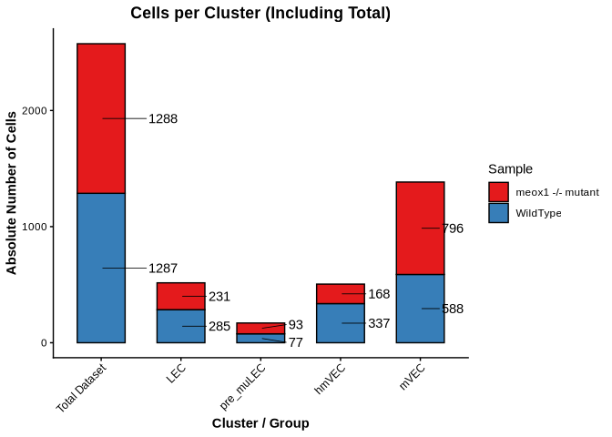

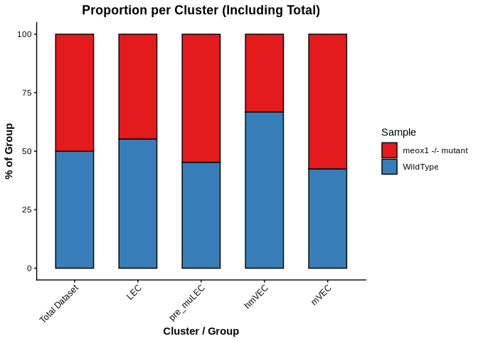

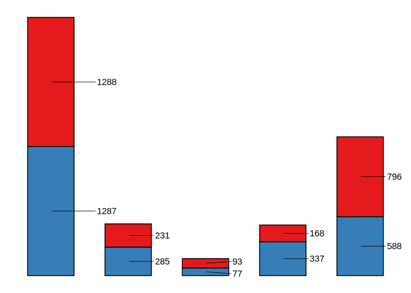

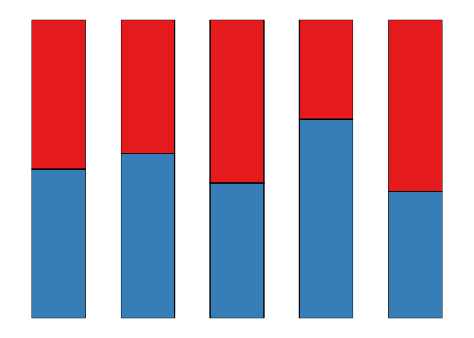

```
## Generating per-sample unified composition barplots...
```

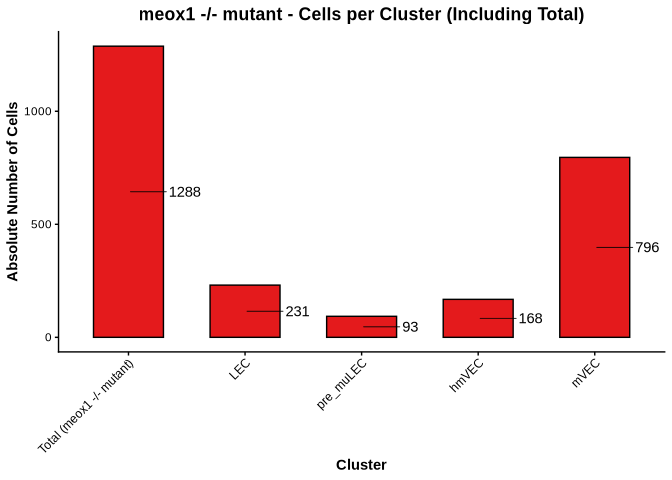

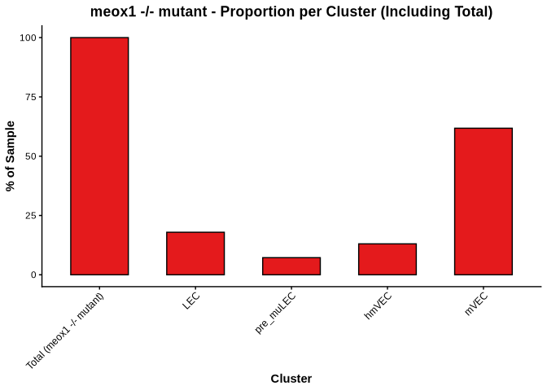

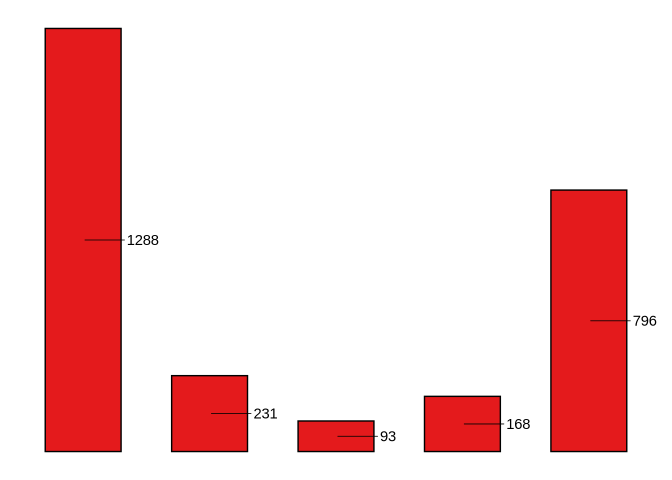

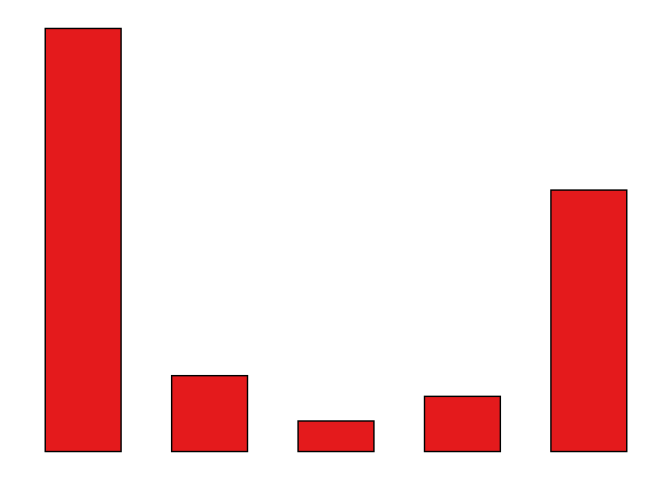

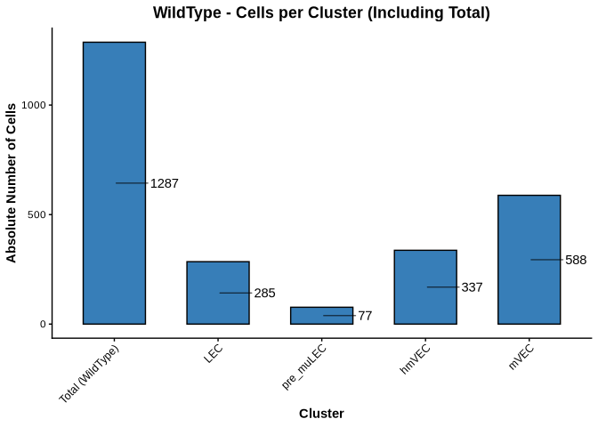

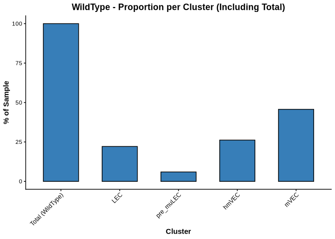

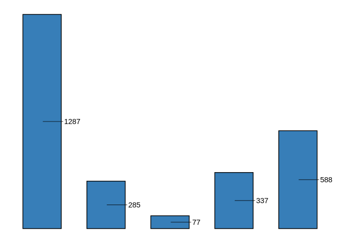

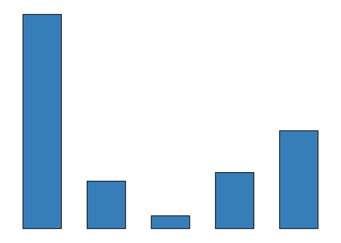

```
## Processing lineage: Slingshot_Pseudotime_start_LEC_lin1
##  Slingshot_Pseudotime_start_LEC_lin1
##  Min.   : 0.000
##  1st Qu.: 7.586
##  Median :11.187
##  Mean   :10.892
##  3rd Qu.:14.387
##  Max.   :20.078
##  NA's   :214
```

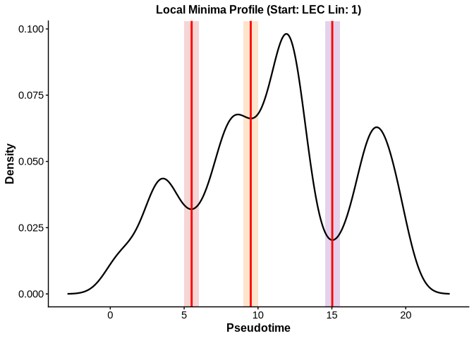

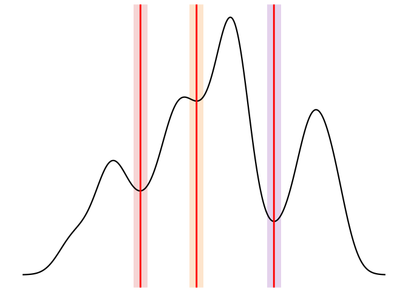

```
##
##    -> [tradeSeq] Initializing GAM fit for start: LEC lin: 1
##       -> Fitting GAMs (this may take a few minutes)...
```

```
## Fitting lineages with multiple conditions. This method has been tested on a couple of datasets, but is still in an experimental phase.
```

```
##       -> Testing Baseline Trajectory Associations...
##       -> Testing Genotype Divergence (WT vs Mut)...
##       -> Generating Smoothed Heatmaps...
```

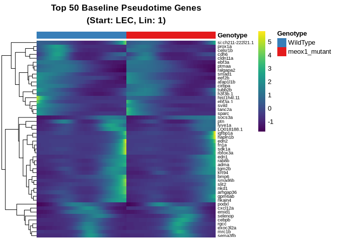

```
## Processing lineage: Slingshot_Pseudotime_start_LEC_lin2
##  Slingshot_Pseudotime_start_LEC_lin2
##  Min.   :0.000
##  1st Qu.:3.226
##  Median :5.606
##  Mean   :5.465
##  3rd Qu.:7.788
##  Max.   :9.994
##  NA's   :1941
```

```
##
##    -> [tradeSeq] Initializing GAM fit for start: LEC lin: 2
##       -> Fitting GAMs (this may take a few minutes)...
```

```
## Fitting lineages with multiple conditions. This method has been tested on a couple of datasets, but is still in an experimental phase.
```

```
##       -> Testing Baseline Trajectory Associations...
##       -> Testing Genotype Divergence (WT vs Mut)...
##       -> Generating Smoothed Heatmaps...
```

```
##       -> 23/34 requested genes (67.6%) not in fitted models object for Top 50 Genotype Divergence Genes
## (Start: LEC, Lin: 2) - dropped.
```

```
## Processing lineage: Slingshot_Pseudotime_start_mVEC_lin1
##  Slingshot_Pseudotime_start_mVEC_lin1
##  Min.   : 0.000
##  1st Qu.: 2.503
##  Median : 5.305
##  Mean   : 6.318
##  3rd Qu.:10.196
##  Max.   :15.943
##  NA's   :541
```

```
##
##    -> [tradeSeq] Initializing GAM fit for start: mVEC lin: 1
##       -> Fitting GAMs (this may take a few minutes)...
```

```
## Fitting lineages with multiple conditions. This method has been tested on a couple of datasets, but is still in an experimental phase.
```

```
##       -> Testing Baseline Trajectory Associations...
##       -> Testing Genotype Divergence (WT vs Mut)...
##       -> Generating Smoothed Heatmaps...
```

```
## Generating custom 2-zone percentage plots for mVEC lineage 1...
```

```
## Processing lineage: Slingshot_Pseudotime_start_mVEC_lin2
##  Slingshot_Pseudotime_start_mVEC_lin2
##  Min.   : 0.000
##  1st Qu.: 2.277
##  Median : 4.849
##  Mean   : 5.676
##  3rd Qu.: 9.330
##  Max.   :12.547
##  NA's   :788
```

```
##
##    -> [tradeSeq] Initializing GAM fit for start: mVEC lin: 2
##       -> Fitting GAMs (this may take a few minutes)...
```

```
## Fitting lineages with multiple conditions. This method has been tested on a couple of datasets, but is still in an experimental phase.
```

```
##       -> Testing Baseline Trajectory Associations...
##       -> Testing Genotype Divergence (WT vs Mut)...
##       -> Generating Smoothed Heatmaps...
```

```
## Generating custom 2-zone percentage plots for mVEC lineage 2...
```

```
## Processing lineage: Slingshot_Pseudotime_start_pre_muLEC_lin1
##  Slingshot_Pseudotime_start_pre_muLEC_lin1
##  Min.   : 0.00
##  1st Qu.: 7.01
##  Median :11.60
##  Mean   :11.03
##  3rd Qu.:14.19
##  Max.   :20.32
```

```
##
##    -> [tradeSeq] Initializing GAM fit for start: pre_muLEC lin: 1
##       -> Fitting GAMs (this may take a few minutes)...
```

```
## Fitting lineages with multiple conditions. This method has been tested on a couple of datasets, but is still in an experimental phase.
```

```
##       -> Testing Baseline Trajectory Associations...
##       -> Testing Genotype Divergence (WT vs Mut)...
##       -> Generating Smoothed Heatmaps...
```

```
## Processing lineage: Slingshot_Pseudotime_start_hmVEC_lin1
##  Slingshot_Pseudotime_start_hmVEC_lin1
##  Min.   : 0.000
##  1st Qu.: 6.128
##  Median : 8.716
##  Mean   : 9.284
##  3rd Qu.:13.309
##  Max.   :20.319
```

```
##
##    -> [tradeSeq] Initializing GAM fit for start: hmVEC lin: 1
##       -> Fitting GAMs (this may take a few minutes)...
```

```
## Fitting lineages with multiple conditions. This method has been tested on a couple of datasets, but is still in an experimental phase.
```

```
##       -> Testing Baseline Trajectory Associations...
##       -> Testing Genotype Divergence (WT vs Mut)...
##       -> Generating Smoothed Heatmaps...
```

```
## Generating custom 3-zone percentage plots for hmVEC lineage 1...
```

```
## Generating custom zone plots for: hmVEC Lin 1 (WT Only) (Dataset: D10051)...
```

```
## Generating custom zone plots for: hmVEC Lin 1 (meox -/- Only) (Dataset: D10051)...
```

```r
run_slingshot(data_S20200, col_map, col_order, col_name="S20200")
```

```
## Generating dataset-level composition barplots...
```

```
## Generating per-sample unified composition barplots...
```

```
## Processing lineage: Slingshot_Pseudotime_start_LEC_lin1
##  Slingshot_Pseudotime_start_LEC_lin1
##  Min.   : 0.00
##  1st Qu.: 7.49
##  Median :10.79
##  Mean   :10.23
##  3rd Qu.:12.44
##  Max.   :18.93
##  NA's   :142
```

```
##
##    -> [tradeSeq] Initializing GAM fit for start: LEC lin: 1
##       -> Missing one genotype condition in this lineage. Skipping divergence test.
```

```
## Processing lineage: Slingshot_Pseudotime_start_LEC_lin2
##  Slingshot_Pseudotime_start_LEC_lin2
##  Min.   :0.000
##  1st Qu.:3.249
##  Median :5.947
##  Mean   :5.578
##  3rd Qu.:7.964
##  Max.   :9.992
##  NA's   :967
```

```
##
##    -> [tradeSeq] Initializing GAM fit for start: LEC lin: 2
##       -> Missing one genotype condition in this lineage. Skipping divergence test.
```

```
## Processing lineage: Slingshot_Pseudotime_start_mVEC_lin1
##  Slingshot_Pseudotime_start_mVEC_lin1
##  Min.   : 0.000
##  1st Qu.: 2.205
##  Median : 4.417
##  Mean   : 5.699
##  3rd Qu.: 9.246
##  Max.   :15.140
##  NA's   :213
```

```
##
##    -> [tradeSeq] Initializing GAM fit for start: mVEC lin: 1
##       -> Missing one genotype condition in this lineage. Skipping divergence test.
```

```
## Generating custom 2-zone percentage plots for mVEC lineage 1...
```

```
## Processing lineage: Slingshot_Pseudotime_start_mVEC_lin2
##  Slingshot_Pseudotime_start_mVEC_lin2
##  Min.   : 0.000
##  1st Qu.: 1.976
##  Median : 3.732
##  Mean   : 4.760
##  3rd Qu.: 7.066
##  Max.   :12.471
##  NA's   :375
```

```
##
##    -> [tradeSeq] Initializing GAM fit for start: mVEC lin: 2
##       -> Missing one genotype condition in this lineage. Skipping divergence test.
```

```
## Generating custom 2-zone percentage plots for mVEC lineage 2...
```

```
## Processing lineage: Slingshot_Pseudotime_start_pre_muLEC_lin1
##  Slingshot_Pseudotime_start_pre_muLEC_lin1
##  Min.   : 0.000
##  1st Qu.: 6.658
##  Median :11.801
##  Mean   :10.824
##  3rd Qu.:13.571
##  Max.   :20.279
```

```
##
##    -> [tradeSeq] Initializing GAM fit for start: pre_muLEC lin: 1
##       -> Missing one genotype condition in this lineage. Skipping divergence test.
```

```
## Processing lineage: Slingshot_Pseudotime_start_hmVEC_lin1
##  Slingshot_Pseudotime_start_hmVEC_lin1
##  Min.   : 0.000
##  1st Qu.: 6.708
##  Median : 8.478
##  Mean   : 9.456
##  3rd Qu.:13.621
##  Max.   :20.280
```

```
##
##    -> [tradeSeq] Initializing GAM fit for start: hmVEC lin: 1
##       -> Missing one genotype condition in this lineage. Skipping divergence test.
```

```
## Generating custom 3-zone percentage plots for hmVEC lineage 1...
```

```
## Generating custom zone plots for: hmVEC Lin 1 (meox -/- Only) (Dataset: S20200)...
```

```r
run_slingshot(data_S20201, col_map, col_order, col_name="S20201")
```

```
## Generating dataset-level composition barplots...
```

```
## Generating per-sample unified composition barplots...
```

```
## Processing lineage: Slingshot_Pseudotime_start_hmVEC_lin1
##  Slingshot_Pseudotime_start_hmVEC_lin1
##  Min.   : 0.000
##  1st Qu.: 3.200
##  Median : 8.483
##  Mean   : 8.873
##  3rd Qu.:12.984
##  Max.   :20.190
```

```
##
##    -> [tradeSeq] Initializing GAM fit for start: hmVEC lin: 1
##       -> Missing one genotype condition in this lineage. Skipping divergence test.
```

```
## Generating custom 3-zone percentage plots for hmVEC lineage 1...
```

```
## Generating custom zone plots for: hmVEC Lin 1 (WT Only) (Dataset: S20201)...
```

```
## Processing lineage: Slingshot_Pseudotime_start_mVEC_lin1
##  Slingshot_Pseudotime_start_mVEC_lin1
##  Min.   : 0.000
##  1st Qu.: 3.137
##  Median : 6.380
##  Mean   : 7.130
##  3rd Qu.:11.174
##  Max.   :16.847
##  NA's   :380
```

```
##
##    -> [tradeSeq] Initializing GAM fit for start: mVEC lin: 1
##       -> Missing one genotype condition in this lineage. Skipping divergence test.
```

```
## Generating custom 2-zone percentage plots for mVEC lineage 1...
```

```
## Processing lineage: Slingshot_Pseudotime_start_mVEC_lin2
##  Slingshot_Pseudotime_start_mVEC_lin2
##  Min.   : 0.000
##  1st Qu.: 3.203
##  Median : 6.611
##  Mean   : 6.564
##  3rd Qu.:10.196
##  Max.   :12.293
##  NA's   :393
```

```
##
##    -> [tradeSeq] Initializing GAM fit for start: mVEC lin: 2
##       -> Missing one genotype condition in this lineage. Skipping divergence test.
```

```
## Generating custom 2-zone percentage plots for mVEC lineage 2...
```

```
## Processing lineage: Slingshot_Pseudotime_start_LEC_lin1
##  Slingshot_Pseudotime_start_LEC_lin1
##  Min.   : 0.1688
##  1st Qu.: 7.3903
##  Median :11.4924
##  Mean   :11.3167
##  3rd Qu.:16.8431
##  Max.   :19.6603
##  NA's   :158
```

```
##
##    -> [tradeSeq] Initializing GAM fit for start: LEC lin: 1
##       -> Missing one genotype condition in this lineage. Skipping divergence test.
```

```
## Processing lineage: Slingshot_Pseudotime_start_LEC_lin2
##  Slingshot_Pseudotime_start_LEC_lin2
##  Min.   : 0.000
##  1st Qu.: 2.580
##  Median : 4.120
##  Mean   : 6.217
##  3rd Qu.: 9.141
##  Max.   :14.917
##  NA's   :912
```

```
##
##    -> [tradeSeq] Initializing GAM fit for start: LEC lin: 2
##       -> Missing one genotype condition in this lineage. Skipping divergence test.
```

```
## Processing lineage: Slingshot_Pseudotime_start_pre_muLEC_lin1
##  Slingshot_Pseudotime_start_pre_muLEC_lin1
##  Min.   : 0.000
##  1st Qu.: 7.206
##  Median :11.707
##  Mean   :11.317
##  3rd Qu.:16.990
##  Max.   :20.190
```

```
##
##    -> [tradeSeq] Initializing GAM fit for start: pre_muLEC lin: 1
##       -> Missing one genotype condition in this lineage. Skipping divergence test.
```

```r
features <- c("mki67", "pcna")
# run_featureplot(data_D10051, features, outfile_dir)  # left disabled to match source (never actually called)
```

## 1.9 Full output file listing (as originally catalogued in the source script header)

```
# hmVEC
    meox1__FeaLabel_Pseudotime_Contours_start_hmVEC_lin1.D10051.pdf
    meox1__FeaLabel_Pseudotime_Contours_start_hmVEC_lin1.S20200.pdf
    meox1__FeaLabel_Pseudotime_Contours_start_hmVEC_lin1.S20201.pdf
    meox1__FeaStrip_Pseudotime_Contours_start_hmVEC_lin1.D10051.pdf
    meox1__FeaStrip_Pseudotime_Contours_start_hmVEC_lin1.S20200.pdf
    meox1__FeaStrip_Pseudotime_Contours_start_hmVEC_lin1.S20201.pdf

# mVEC
    meox1__FeaLabel_Pseudotime_Contours_start_mVEC_lin1.D10051.pdf
    meox1__FeaLabel_Pseudotime_Contours_start_mVEC_lin1.S20200.pdf
    meox1__FeaLabel_Pseudotime_Contours_start_mVEC_lin1.S20201.pdf
    meox1__FeaStrip_Pseudotime_Contours_start_mVEC_lin1.D10051.pdf
    meox1__FeaStrip_Pseudotime_Contours_start_mVEC_lin1.S20200.pdf
    meox1__FeaStrip_Pseudotime_Contours_start_mVEC_lin1.S20201.pdf
    meox1__FeaLabel_Pseudotime_Contours_start_mVEC_lin2.D10051.pdf
    meox1__FeaLabel_Pseudotime_Contours_start_mVEC_lin2.S20200.pdf
    meox1__FeaLabel_Pseudotime_Contours_start_mVEC_lin2.S20201.pdf
    meox1__FeaStrip_Pseudotime_Contours_start_mVEC_lin2.D10051.pdf
    meox1__FeaStrip_Pseudotime_Contours_start_mVEC_lin2.S20200.pdf
    meox1__FeaStrip_Pseudotime_Contours_start_mVEC_lin2.S20201.pdf
    meox1__BarLabel_Isolated_Zones_Stacked_Proportion_start_mVEC_lin1.D10051.pdf
    meox1__BarStrip_Isolated_Zones_Stacked_Proportion_start_mVEC_lin1.D10051.pdf
    meox1__BarLabel_Isolated_Zones_Stacked_Proportion_start_mVEC_lin2.D10051.pdf
    meox1__BarStrip_Isolated_Zones_Stacked_Proportion_start_mVEC_lin2.D10051.pdf
    meox1__BarLabel_Custom_mVEC_Lin1_Zones12_Stacked_Proportion.pdf
    meox1__BarStrip_Custom_mVEC_Lin1_Zones12_Stacked_Proportion.pdf
    meox1__BarLabel_Custom_mVEC_Lin1_Zones12_Dodged_Proportion.pdf
    meox1__BarStrip_Custom_mVEC_Lin1_Zones12_Dodged_Proportion.pdf
    meox1__BarLabel_Custom_mVEC_Lin2_Zones12_Stacked_Proportion.pdf
    meox1__BarStrip_Custom_mVEC_Lin2_Zones12_Stacked_Proportion.pdf
    meox1__BarLabel_Custom_mVEC_Lin2_Zones12_Dodged_Proportion.pdf
    meox1__BarStrip_Custom_mVEC_Lin2_Zones12_Dodged_Proportion.pdf
    meox1__DensLabel_Minima_start_mVEC_lin1.D10051.pdf
    meox1__DensLabel_Minima_start_mVEC_lin1.S20200.pdf
    meox1__DensLabel_Minima_start_mVEC_lin1.S20201.pdf
    meox1__DensLabel_Minima_start_mVEC_lin2.D10051.pdf
    meox1__DensLabel_Minima_start_mVEC_lin2.S20200.pdf
    meox1__DensLabel_Minima_start_mVEC_lin2.S20201.pdf

```

[output cut: 25 more lines]

```
# WT-anchored head-to-head (mVEC lin1/lin2)
    meox1__DensLabel_WT_Anchored_Overlay_Direct_HeadToHead_start_mVEC_lin1.pdf
    meox1__BarLabel_WT_Anchored_Quantified_Proportions_start_mVEC_lin1.pdf
    meox1__DensLabel_WT_Anchored_Overlay_Direct_HeadToHead_start_mVEC_lin2.pdf
    meox1__BarLabel_WT_Anchored_Quantified_Proportions_start_mVEC_lin2.pdf

# WT-anchored UMAP contours (hmVEC lin1)
    meox1__DimLabel_WT_Anchored_Contours_Combined_start_hmVEC_lin1.pdf
    meox1__DimLabel_WT_Anchored_Contours_Split_start_hmVEC_lin1.pdf

# WT-anchored UMAP contours (mVEC lin1/lin2)
    meox1__DimLabel_WT_Anchored_Contours_Combined_start_mVEC_lin1.pdf
    meox1__DimLabel_WT_Anchored_Contours_Split_start_mVEC_lin1.pdf
    meox1__DimLabel_WT_Anchored_Contours_Combined_start_mVEC_lin2.pdf
    meox1__DimLabel_WT_Anchored_Contours_Split_start_mVEC_lin2.pdf
```

Note: `S20200` is mutant and `S20201` is wildtype.

## 1.10 For developers

Sample run command:

```bash
Rscript -e "
rmarkdown::render(
  'meox1_slingshot_pseudotime.Rmd',
  output_file = './meox1_slingshot_pseudotime.html'
)
"
```